# Supervised Learning : Modelling Right-Censored Survival Time and Status Responses for Prediction

## 1.5. Data Exploration

### 1.5.1 Exploratory Data Analysis

1. The estimated baseline survival plot indicated a 50% survival rate at N_Days=3358.
2. Bivariate analysis identified individual predictors with potential association to the event status based on visual inspection.
   - Higher values for the following numeric predictors are associated with Status=True:
     - Age
     - Bilirubin
     - Copper
     - Alk_Phos
     - SGOT
     - Tryglicerides
     - Prothrombin
   - Higher counts for the following object predictors are associated with better differentiation between Status=True and Status=False:
     - Drug
     - Sex
     - Ascites
     - Hepatomegaly
     - Spiders
     - Edema
     - Stage_1.0
     - Stage_2.0
     - Stage_3.0
     - Stage_4.0
3. Bivariate analysis identified individual predictors with potential association to the survival time based on visual inspection.
   - Higher values for the following numeric predictors are positively associated with N_Days:
     - Albumin
     - Platelets
   - Levels for the following object predictors are associated with differences in N_Days between Status=True and Status=False:
     - Drug
     - Sex
     - Ascites
     - Hepatomegaly
     - Spiders
     - Edema
     - Stage_1.0
     - Stage_2.0
     - Stage_3.0
     - Stage_4.0

```python
##################################
# Formulating a complete dataframe
# from the training subset for EDA
##################################
cirrhosis_survival_y_train_cleaned.reset_index(drop=True, inplace=True)
cirrhosis_survival_train_EDA = pd.concat([cirrhosis_survival_y_train_cleaned,
                                          cirrhosis_survival_X_train_preprocessed],
                                         axis=1)
cirrhosis_survival_train_EDA.head()
```

|  | Status | N_Days | Age | Bilirubin | Cholesterol | Albumin | Copper | Alk_Phos | SGOT | Tryglicerides | ... | Drug | Sex | Ascites | Hepatomegaly | Spiders | Edema | Stage_1.0 | Stage_2.0 | Stage_3.0 | Stage_4.0 |
| --- | --- | --- | --- | --- | --- | --- | --- | --- | --- | --- | --- | --- | --- | --- | --- | --- | --- | --- | --- | --- | --- |
| 0 | False | 2475 | -1.342097 | 0.863802 | 0.886087 | -0.451884 | -0.972098 | 0.140990 | 0.104609 | 0.155130 | ... | 1 | 1 | 0 | 0 | 0 | 0 | 0 | 1 | 0 | 0 |
| 1 | False | 877 | -1.470901 | 0.516350 | 1.554523 | 0.827618 | 0.467579 | -0.705337 | 0.301441 | 1.275222 | ... | 1 | 0 | 0 | 0 | 0 | 0 | 0 | 0 | 1 | 0 |
| 2 | False | 3050 | -0.239814 | -0.625875 | 0.293280 | 0.646582 | -0.241205 | -0.848544 | 0.275723 | -1.684460 | ... | 1 | 1 | 0 | 0 | 0 | 0 | 0 | 1 | 0 | 0 |
| 3 | True | 110 | -0.052733 | 0.559437 | -1.534283 | 0.354473 | -0.284113 | -0.014525 | 0.162878 | -0.189139 | ... | 0 | 1 | 1 | 1 | 1 | 1 | 0 | 0 | 0 | 1 |
| 4 | True | 3839 | -0.795010 | 1.142068 | -0.108933 | -0.272913 | 0.618030 | 2.071847 | 1.434674 | -0.212684 | ... | 0 | 1 | 0 | 1 | 0 | 0 | 0 | 1 | 0 | 0 |

5 rows × 22 columns

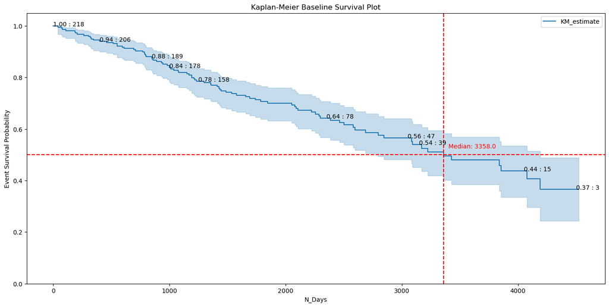

```python
##################################
# Plotting the baseline survival curve
# and computing the survival rates
##################################
kmf = KaplanMeierFitter()
kmf.fit(durations=cirrhosis_survival_train_EDA['N_Days'], event_observed=cirrhosis_survival_train_EDA['Status'])
plt.figure(figsize=(17, 8))
kmf.plot_survival_function()
plt.title('Kaplan-Meier Baseline Survival Plot')
plt.ylim(0, 1.05)
plt.xlabel('N_Days')
plt.ylabel('Event Survival Probability')

##################################
# Determing the at-risk numbers
##################################
at_risk_counts = kmf.event_table.at_risk
survival_probabilities = kmf.survival_function_.values.flatten()
time_points = kmf.survival_function_.index
for time, prob, at_risk in zip(time_points, survival_probabilities, at_risk_counts):
    if time % 50 == 0:
        plt.text(time, prob, f'{prob:.2f} : {at_risk}', ha='left', fontsize=10)
median_survival_time = kmf.median_survival_time_
plt.axvline(x=median_survival_time, color='r', linestyle='--')
plt.axhline(y=0.5, color='r', linestyle='--')
plt.text(3400, 0.52, f'Median: {median_survival_time}', ha='left', va='bottom', color='r', fontsize=10)
plt.show()
```

```python
##################################
# Computing the median survival time
##################################
median_survival_time = kmf.median_survival_time_
print(f'Median Survival Time: {median_survival_time}')
```

```
Median Survival Time: 3358.0
```

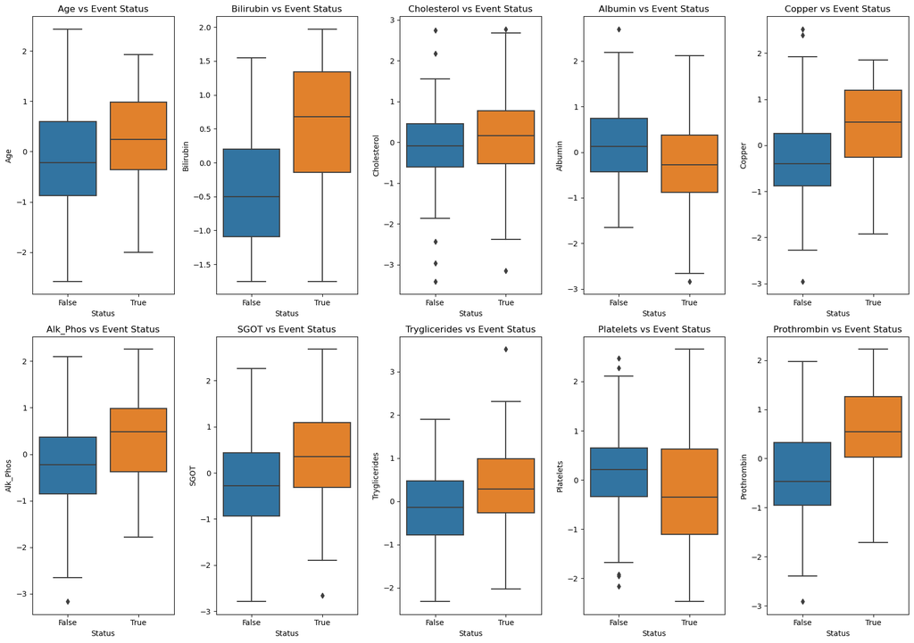

```python
##################################
# Exploring the relationships between
# the numeric predictors and event status
##################################
cirrhosis_survival_numeric_predictors = ['Age', 'Bilirubin','Cholesterol', 'Albumin','Copper', 'Alk_Phos','SGOT', 'Tryglicerides','Platelets', 'Prothrombin']
plt.figure(figsize=(17, 12))
for i in range(1, 11):
    plt.subplot(2, 5, i)
    sns.boxplot(x='Status', y=cirrhosis_survival_numeric_predictors[i-1], data=cirrhosis_survival_train_EDA)
    plt.title(f'{cirrhosis_survival_numeric_predictors[i-1]} vs Event Status')
plt.tight_layout()
plt.show()
```

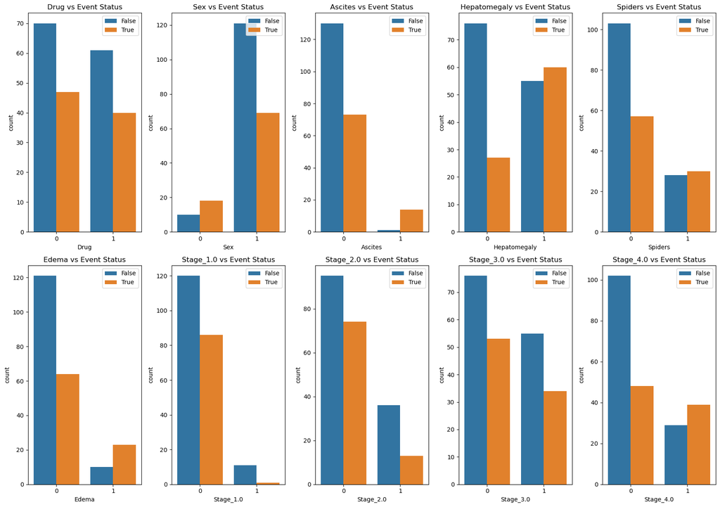

```python
##################################
# Exploring the relationships between
# the object predictors and event status
##################################
cirrhosis_survival_object_predictors = ['Drug', 'Sex','Ascites', 'Hepatomegaly','Spiders', 'Edema','Stage_1.0','Stage_2.0','Stage_3.0','Stage_4.0']
plt.figure(figsize=(17, 12))
for i in range(1, 11):
    plt.subplot(2, 5, i)
    sns.countplot(x=cirrhosis_survival_object_predictors[i-1], hue='Status', data=cirrhosis_survival_train_EDA)
    plt.title(f'{cirrhosis_survival_object_predictors[i-1]} vs Event Status')
    plt.legend(loc='upper right')
plt.tight_layout()
plt.show()
```

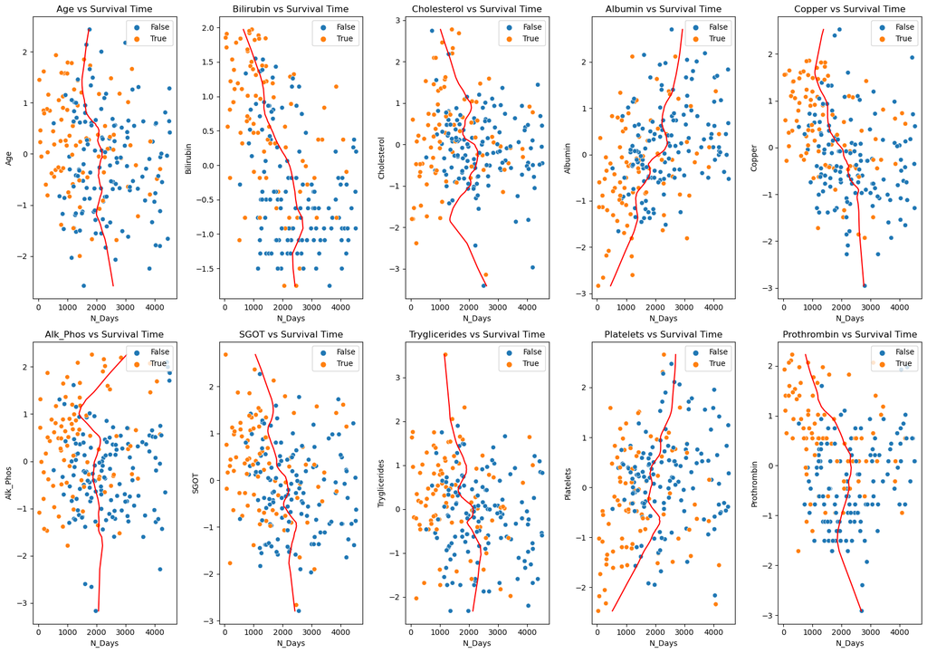

```python
##################################
# Exploring the relationships between
# the numeric predictors and survival time
##################################
plt.figure(figsize=(17, 12))
for i in range(1, 11):
    plt.subplot(2, 5, i)
    sns.scatterplot(x='N_Days', y=cirrhosis_survival_numeric_predictors[i-1], data=cirrhosis_survival_train_EDA, hue='Status')
    loess_smoothed = lowess(cirrhosis_survival_train_EDA['N_Days'], cirrhosis_survival_train_EDA[cirrhosis_survival_numeric_predictors[i-1]], frac=0.3)
    plt.plot(loess_smoothed[:, 1], loess_smoothed[:, 0], color='red')
    plt.title(f'{cirrhosis_survival_numeric_predictors[i-1]} vs Survival Time')
    plt.legend(loc='upper right')
plt.tight_layout()
plt.show()
```

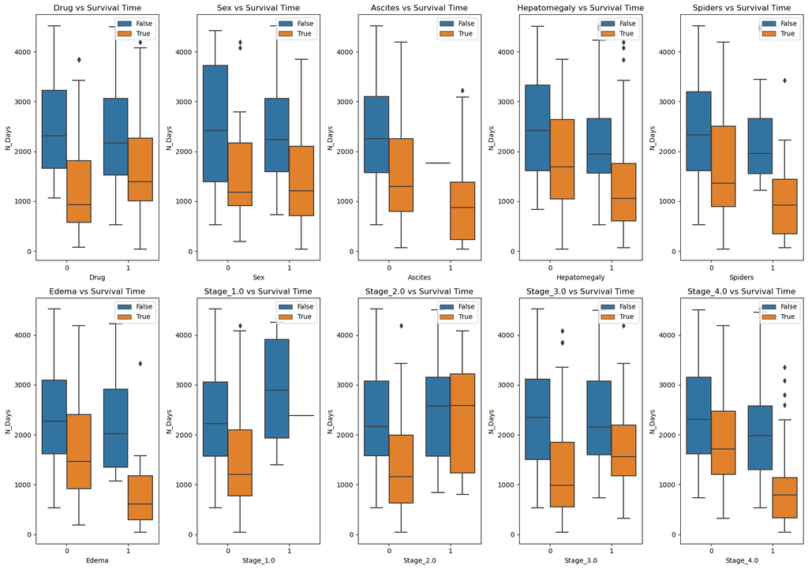

```python
##################################
# Exploring the relationships between
# the object predictors and survival time
##################################
plt.figure(figsize=(17, 12))
for i in range(1, 11):
    plt.subplot(2, 5, i)
    sns.boxplot(x=cirrhosis_survival_object_predictors[i-1], y='N_Days', hue='Status', data=cirrhosis_survival_train_EDA)
    plt.title(f'{cirrhosis_survival_object_predictors[i-1]} vs Survival Time')
    plt.legend(loc='upper right')
plt.tight_layout()
plt.show()
```

### 1.5.2 Hypothesis Testing

```python
##################################
# Computing the t-test
# statistic and p-values
# between the event variable
# and numeric predictor columns
##################################
cirrhosis_survival_numeric_ttest_event = {}
for numeric_column in cirrhosis_survival_numeric_predictors:
    group_0 = cirrhosis_survival_train_EDA[cirrhosis_survival_train_EDA.loc[:,'Status']==False]
    group_1 = cirrhosis_survival_train_EDA[cirrhosis_survival_train_EDA.loc[:,'Status']==True]
    cirrhosis_survival_numeric_ttest_event['Status_' + numeric_column] = stats.ttest_ind(
        group_0[numeric_column],
        group_1[numeric_column],
        equal_var=True)
```

```python
##################################
# Formulating the pairwise ttest summary
# between the event variable
# and numeric predictor columns
##################################
cirrhosis_survival_numeric_ttest_summary = cirrhosis_survival_train_EDA.from_dict(cirrhosis_survival_numeric_ttest_event, orient='index')
cirrhosis_survival_numeric_ttest_summary.columns = ['T.Test.Statistic', 'T.Test.PValue']
display(cirrhosis_survival_numeric_ttest_summary.sort_values(by=['T.Test.PValue'], ascending=True))
```

|  | T.Test.Statistic | T.Test.PValue |
| --- | --- | --- |
| Status_Bilirubin | -8.030789 | 6.198797e-14 |
| Status_Prothrombin | -7.062933 | 2.204961e-11 |
| Status_Copper | -5.699409 | 3.913575e-08 |
| Status_Alk_Phos | -4.638524 | 6.077981e-06 |
| Status_SGOT | -4.207123 | 3.791642e-05 |
| Status_Albumin | 3.871216 | 1.434736e-04 |
| Status_Tryglicerides | -3.575779 | 4.308371e-04 |
| Status_Age | -3.264563 | 1.274679e-03 |
| Status_Platelets | 3.261042 | 1.289850e-03 |
| Status_Cholesterol | -2.256073 | 2.506758e-02 |

```python
##################################
# Computing the chisquare
# statistic and p-values
# between the event variable
# and categorical predictor columns
##################################
cirrhosis_survival_object_chisquare_event = {}
for object_column in cirrhosis_survival_object_predictors:
    contingency_table = pd.crosstab(cirrhosis_survival_train_EDA[object_column],
                                    cirrhosis_survival_train_EDA['Status'])
    cirrhosis_survival_object_chisquare_event['Status_' + object_column] = stats.chi2_contingency(
        contingency_table)[0:2]
```

```python
##################################
# Formulating the pairwise chisquare summary
# between the event variable
# and categorical predictor columns
##################################
cirrhosis_survival_object_chisquare_event_summary = cirrhosis_survival_train_EDA.from_dict(cirrhosis_survival_object_chisquare_event, orient='index')
cirrhosis_survival_object_chisquare_event_summary.columns = ['ChiSquare.Test.Statistic', 'ChiSquare.Test.PValue']
display(cirrhosis_survival_object_chisquare_event_summary.sort_values(by=['ChiSquare.Test.PValue'], ascending=True))
```

|  | ChiSquare.Test.Statistic | ChiSquare.Test.PValue |
| --- | --- | --- |
| Status_Ascites | 16.854134 | 0.000040 |
| Status_Hepatomegaly | 14.206045 | 0.000164 |
| Status_Edema | 12.962303 | 0.000318 |
| Status_Stage_4.0 | 11.505826 | 0.000694 |
| Status_Sex | 6.837272 | 0.008928 |
| Status_Stage_2.0 | 4.024677 | 0.044839 |
| Status_Stage_1.0 | 3.977918 | 0.046101 |
| Status_Spiders | 3.953826 | 0.046765 |
| Status_Stage_3.0 | 0.082109 | 0.774459 |
| Status_Drug | 0.000000 | 1.000000 |

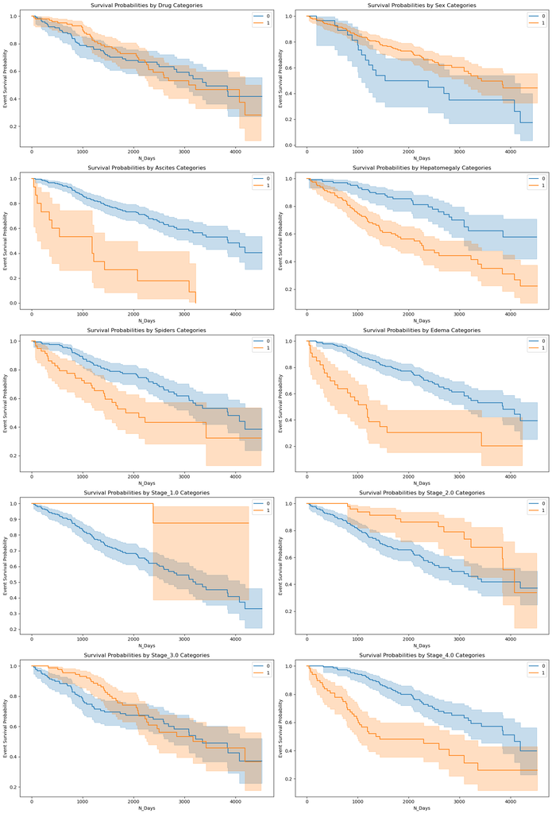

```python
##################################
# Exploring the relationships between
# the object predictors with
# survival event and duration
##################################
plt.figure(figsize=(17, 25))
for i in range(0, len(cirrhosis_survival_object_predictors)):
    ax = plt.subplot(5, 2, i+1)
    for group in [0,1]:
        kmf.fit(durations=cirrhosis_survival_train_EDA[cirrhosis_survival_train_EDA[cirrhosis_survival_object_predictors[i]] == group]['N_Days'],
                event_observed=cirrhosis_survival_train_EDA[cirrhosis_survival_train_EDA[cirrhosis_survival_object_predictors[i]] == group]['Status'], label=group)
        kmf.plot_survival_function(ax=ax)
    plt.title(f'Survival Probabilities by {cirrhosis_survival_object_predictors[i]} Categories')
    plt.xlabel('N_Days')
    plt.ylabel('Event Survival Probability')
plt.tight_layout()
plt.show()
```

```python
##################################
# Computing the log-rank test
# statistic and p-values
# between the event and duration variables
# with the object predictor columns
##################################
cirrhosis_survival_object_lrtest_event = {}
for object_column in cirrhosis_survival_object_predictors:
    groups = [0,1]
    group_0_event = cirrhosis_survival_train_EDA[cirrhosis_survival_train_EDA[object_column] == groups[0]]['Status']
    group_1_event = cirrhosis_survival_train_EDA[cirrhosis_survival_train_EDA[object_column] == groups[1]]['Status']
    group_0_duration = cirrhosis_survival_train_EDA[cirrhosis_survival_train_EDA[object_column] == groups[0]]['N_Days']
    group_1_duration = cirrhosis_survival_train_EDA[cirrhosis_survival_train_EDA[object_column] == groups[1]]['N_Days']
    lr_test = logrank_test(group_0_duration, group_1_duration,event_observed_A=group_0_event, event_observed_B=group_1_event)
    cirrhosis_survival_object_lrtest_event['Status_NDays_' + object_column] = (lr_test.test_statistic, lr_test.p_value)
```

```python
##################################
# Formulating the log-rank test summary
# between the event and duration variables
# with the object predictor columns
##################################
cirrhosis_survival_object_lrtest_summary = cirrhosis_survival_train_EDA.from_dict(cirrhosis_survival_object_lrtest_event, orient='index')
cirrhosis_survival_object_lrtest_summary.columns = ['LR.Test.Statistic', 'LR.Test.PValue']
display(cirrhosis_survival_object_lrtest_summary.sort_values(by=['LR.Test.PValue'], ascending=True))
```

|  | LR.Test.Statistic | LR.Test.PValue |
| --- | --- | --- |
| Status_NDays_Ascites | 37.792220 | 7.869499e-10 |
| Status_NDays_Edema | 31.619652 | 1.875223e-08 |
| Status_NDays_Stage_4.0 | 26.482676 | 2.659121e-07 |
| Status_NDays_Hepatomegaly | 20.360210 | 6.414988e-06 |
| Status_NDays_Spiders | 10.762275 | 1.035900e-03 |
| Status_NDays_Stage_2.0 | 6.775033 | 9.244176e-03 |
| Status_NDays_Sex | 5.514094 | 1.886385e-02 |
| Status_NDays_Stage_1.0 | 5.473270 | 1.930946e-02 |
| Status_NDays_Stage_3.0 | 0.478031 | 4.893156e-01 |
| Status_NDays_Drug | 0.000016 | 9.968084e-01 |

```python
##################################
# Creating an alternate copy of the
# EDA data which will utilize
# binning for numeric predictors
##################################
cirrhosis_survival_train_EDA_binned = cirrhosis_survival_train_EDA.copy()

##################################
# Creating a function to bin
# numeric predictors into two groups
##################################
def bin_numeric_predictor(df, predictor):
    median = df[predictor].median()
    df[f'Binned_{predictor}'] = np.where(df[predictor] <= median, 0, 1)
    return df

##################################
# Binning the numeric predictors
# in the alternate EDA data into two groups
##################################
for numeric_column in cirrhosis_survival_numeric_predictors:
    cirrhosis_survival_train_EDA_binned = bin_numeric_predictor(cirrhosis_survival_train_EDA_binned, numeric_column)

##################################
# Formulating the binned numeric predictors
##################################
cirrhosis_survival_binned_numeric_predictors = ["Binned_" + predictor for predictor in cirrhosis_survival_numeric_predictors]
```

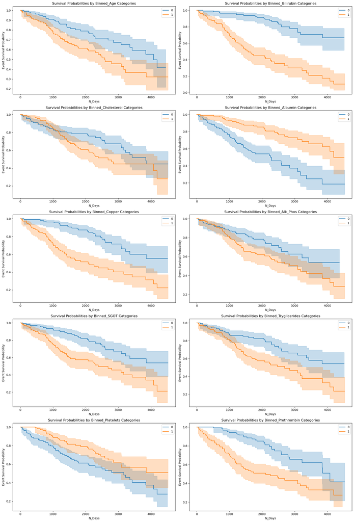

```python
##################################
# Exploring the relationships between
# the binned numeric predictors with
# survival event and duration
##################################
plt.figure(figsize=(17, 25))
for i in range(0, len(cirrhosis_survival_binned_numeric_predictors)):
    ax = plt.subplot(5, 2, i+1)
    for group in [0,1]:
        kmf.fit(durations=cirrhosis_survival_train_EDA_binned[cirrhosis_survival_train_EDA_binned[cirrhosis_survival_binned_numeric_predictors[i]] == group]['N_Days'],
                event_observed=cirrhosis_survival_train_EDA_binned[cirrhosis_survival_train_EDA_binned[cirrhosis_survival_binned_numeric_predictors[i]] == group]['Status'], label=group)
        kmf.plot_survival_function(ax=ax)
    plt.title(f'Survival Probabilities by {cirrhosis_survival_binned_numeric_predictors[i]} Categories')
    plt.xlabel('N_Days')
    plt.ylabel('Event Survival Probability')
plt.tight_layout()
plt.show()
```

```python
##################################
# Computing the log-rank test
# statistic and p-values
# between the event and duration variables
# with the binned numeric predictor columns
##################################
cirrhosis_survival_binned_numeric_lrtest_event = {}
for binned_numeric_column in cirrhosis_survival_binned_numeric_predictors:
    groups = [0,1]
    group_0_event = cirrhosis_survival_train_EDA_binned[cirrhosis_survival_train_EDA_binned[binned_numeric_column] == groups[0]]['Status']
    group_1_event = cirrhosis_survival_train_EDA_binned[cirrhosis_survival_train_EDA_binned[binned_numeric_column] == groups[1]]['Status']
    group_0_duration = cirrhosis_survival_train_EDA_binned[cirrhosis_survival_train_EDA_binned[binned_numeric_column] == groups[0]]['N_Days']
    group_1_duration = cirrhosis_survival_train_EDA_binned[cirrhosis_survival_train_EDA_binned[binned_numeric_column] == groups[1]]['N_Days']
    lr_test = logrank_test(group_0_duration, group_1_duration,event_observed_A=group_0_event, event_observed_B=group_1_event)
    cirrhosis_survival_binned_numeric_lrtest_event['Status_NDays_' + binned_numeric_column] = (lr_test.test_statistic, lr_test.p_value)
```

```python
##################################
# Formulating the log-rank test summary
# between the event and duration variables
# with the binned numeric predictor columns
##################################
cirrhosis_survival_binned_numeric_lrtest_summary = cirrhosis_survival_train_EDA_binned.from_dict(cirrhosis_survival_binned_numeric_lrtest_event, orient='index')
cirrhosis_survival_binned_numeric_lrtest_summary.columns = ['LR.Test.Statistic', 'LR.Test.PValue']
display(cirrhosis_survival_binned_numeric_lrtest_summary.sort_values(by=['LR.Test.PValue'], ascending=True))
```

|  | LR.Test.Statistic | LR.Test.PValue |
| --- | --- | --- |
| Status_NDays_Binned_Bilirubin | 62.559303 | 2.585412e-15 |
| Status_NDays_Binned_Albumin | 29.444808 | 5.753197e-08 |
| Status_NDays_Binned_Copper | 27.452421 | 1.610072e-07 |
| Status_NDays_Binned_Prothrombin | 21.695995 | 3.194575e-06 |
| Status_NDays_Binned_SGOT | 16.178483 | 5.764520e-05 |
| Status_NDays_Binned_Tryglicerides | 11.512960 | 6.911262e-04 |
| Status_NDays_Binned_Age | 9.011700 | 2.682568e-03 |
| Status_NDays_Binned_Platelets | 6.741196 | 9.421142e-03 |
| Status_NDays_Binned_Alk_Phos | 5.503850 | 1.897465e-02 |
| Status_NDays_Binned_Cholesterol | 3.773953 | 5.205647e-02 |

### 1.6.1 Premodelling Data Description

```python
##################################
# Converting the event and duration variables
# for the training set
# to array as preparation for modeling
##################################
cirrhosis_survival_y_train_array = np.array([(row.Status, row.N_Days) for index, row in cirrhosis_survival_y_train_cleaned.iterrows()], dtype=[('Status', 'bool'), ('N_Days', 'int')])
print(cirrhosis_survival_y_train_array)
```

```
[(False, 2475) (False,  877) (False, 3050) ( True,  110) ( True, 3839)
 (False, 2241) (False, 2332) (False, 1666) ( True, 2847) (False, 4500)
 (False, 4256) ( True, 1427) ( True,  943) (False, 2456) (False, 1301)
 (False, 3297) ( True, 1434) ( True, 1297) (False,  839) (False, 2995)
 ( True, 1235) (False,  901) ( True,  264) (False, 1614) ( True, 1360)
 (False, 2835) (False, 3445) ( True,  597) (False, 1250) ( True, 4079)
 ( True, 2055) ( True,  850) ( True, 2105) ( True, 3358) (False, 3707)
 (False, 4032) (False, 2657) (False, 1592) ( True,  400) ( True, 1077)
 (False, 3099) (False, 1951) (False, 2294) (False, 4453) (False, 1978)
 ( True, 2297) ( True,  890) (False, 1979) (False, 1149) (False, 1765)
 ( True, 2689) ( True,  326) (False, 3823) ( True,  191) (False, 4523)
 ( True,  930) (False, 1656) (False, 3149) (False, 1230) ( True, 1012)
 (False, 1831) ( True, 1487) (False, 2563) (False, 1067) ( True, 1741)
 ( True, 2796) ( True, 2386) ( True, 2256) ( True,   77) (False, 3255)
 (False, 3933) (False, 2178) ( True, 1657) (False, 2221) (False, 1677)
 ( True, 1444) ( True, 1786) (False, 1434) (False, 4184) ( True,  321)
 ( True,   71) ( True, 1191) ( True,  786) (False, 1568) ( True, 1037)
 (False, 1769) (False, 2170) (False, 3992) ( True, 1170) (False, 2443)
 (False, 2573) (False, 1615) (False, 1810) ( True, 1000) ( True,  611)
 (False, 1320) ( True, 1217) (False, 2171) ( True, 1152) (False, 1363)
 ( True, 1536) ( True,  797) (False, 1401) (False,  732) (False, 1433)
 (False, 1216) ( True, 2583) (False, 1569) ( True, 3428) ( True, 2466)
 ( True, 3090) (False, 2644) (False, 4365) ( True,  304) (False, 2870)
 (False, 3913) ( True,  552) (False, 1874) (False, 1271) (False,  533)
 (False, 3239) ( True, 1847) (False, 1412) (False, 2195) ( True, 3086)
 (False, 2357) (False, 2713) ( True, 2598) ( True,  694) (False, 1084)
 (False, 2106) (False, 3611) (False, 2555) (False, 3069) ( True,  799)
 ( True,  186) ( True,  769) (False, 3581) ( True, 2503) ( True,  859)
 (False, 1525) (False, 1295) ( True,  999) ( True, 1212) (False, 2350)
 ( True,  980) (False, 2468) (False, 1153) (False, 4196) ( True, 1191)
 (False, 4427) ( True,  348) (False, 2624) (False, 4039) ( True, 2288)
 ( True,  207) ( True,  549) (False, 2504) (False, 3820) ( True, 1356)
 ( True, 3853) (False, 4509) (False, 2216) (False, 1558) ( True, 1576)
 ( True, 2224) (False, 4190) (False, 3059) (False, 2797) (False, 2168)
 (False, 2609) (False, 3150) (False, 2976) (False, 1216) (False, 3672)
 (False, 2157) (False, 1293) ( True,  790) (False, 2891) (False, 1234)
 (False, 2318) (False, 1542) (False, 1790) (False,  939) (False, 2301)
 ( True, 2081) ( True, 2090) (False, 4050) (False, 4127) (False, 2692)
 (False, 1302) ( True, 1080) (False, 1908) ( True, 3222) (False, 1770)
 (False, 2272) (False, 1832) (False, 4025) ( True,   41) ( True,  515)
 ( True,  708) ( True, 1690) (False, 1967) (False, 1945) (False, 1504)
 ( True, 1413) (False, 1702) (False, 3422) (False, 2666) (False, 3092)
 ( True, 4191) (False, 1363) (False, 1932) ( True, 3170) (False, 4232)
 ( True,  460) (False, 1614) ( True,  853)]
```

```python
##################################
# Verifying the predictor variables
# for the training set
# as preparation for modeling
##################################
display(cirrhosis_survival_X_train_preprocessed)
```

|  | Age | Bilirubin | Cholesterol | Albumin | Copper | Alk_Phos | SGOT | Tryglicerides | Platelets | Prothrombin | Drug | Sex | Ascites | Hepatomegaly | Spiders | Edema | Stage_1.0 | Stage_2.0 | Stage_3.0 | Stage_4.0 |
| --- | --- | --- | --- | --- | --- | --- | --- | --- | --- | --- | --- | --- | --- | --- | --- | --- | --- | --- | --- | --- |
| 0 | -1.342097 | 0.863802 | 0.886087 | -0.451884 | -0.972098 | 0.140990 | 0.104609 | 0.155130 | 0.540960 | 0.747580 | 1 | 1 | 0 | 0 | 0 | 0 | 0 | 1 | 0 | 0 |
| 1 | -1.470901 | 0.516350 | 1.554523 | 0.827618 | 0.467579 | -0.705337 | 0.301441 | 1.275222 | 0.474140 | -0.315794 | 1 | 0 | 0 | 0 | 0 | 0 | 0 | 0 | 1 | 0 |
| 2 | -0.239814 | -0.625875 | 0.293280 | 0.646582 | -0.241205 | -0.848544 | 0.275723 | -1.684460 | 0.756741 | 0.087130 | 1 | 1 | 0 | 0 | 0 | 0 | 0 | 1 | 0 | 0 |
| 3 | -0.052733 | 0.559437 | -1.534283 | 0.354473 | -0.284113 | -0.014525 | 0.162878 | -0.189139 | -1.735375 | 0.649171 | 0 | 1 | 1 | 1 | 1 | 1 | 0 | 0 | 0 | 1 |
| 4 | -0.795010 | 1.142068 | -0.108933 | -0.272913 | 0.618030 | 2.071847 | 1.434674 | -0.212684 | -0.675951 | -0.315794 | 0 | 1 | 0 | 1 | 0 | 0 | 0 | 1 | 0 | 0 |
| ... | ... | ... | ... | ... | ... | ... | ... | ... | ... | ... | ... | ... | ... | ... | ... | ... | ... | ... | ... | ... |
| 213 | 0.167351 | -0.764558 | -1.147913 | -0.887287 | 0.178721 | 0.320864 | 1.574157 | 0.053603 | -0.848130 | 1.402075 | 0 | 1 | 0 | 0 | 0 | 0 | 0 | 0 | 1 | 0 |
| 214 | 0.004420 | -0.918484 | -0.782126 | 0.046794 | -0.742780 | 0.549222 | -0.379344 | 0.251836 | -0.519594 | 0.546417 | 1 | 1 | 0 | 1 | 0 | 1 | 0 | 0 | 1 | 0 |
| 215 | -0.381113 | 1.190111 | 0.136728 | -0.194525 | 0.569475 | 0.881231 | 1.871385 | -1.684460 | 1.587388 | 1.331561 | 0 | 1 | 0 | 1 | 1 | 1 | 0 | 0 | 0 | 1 |
| 216 | 0.800410 | -1.283677 | -0.262095 | 2.149157 | -0.836372 | -2.600746 | -1.414105 | 0.645045 | -0.324107 | 0.087130 | 1 | 1 | 0 | 0 | 0 | 0 | 0 | 1 | 0 | 0 |
| 217 | 0.900345 | 1.951372 | 0.375927 | -0.061605 | 1.546419 | 0.884998 | 1.376469 | 1.394391 | -1.196794 | 1.018851 | 0 | 1 | 0 | 1 | 0 | 0 | 0 | 1 | 0 | 0 |

218 rows × 20 columns

```python
##################################
# Converting the event and duration variables
# for the test set
# to array as preparation for modeling
##################################
cirrhosis_survival_y_test_array = np.array([(row.Status, row.N_Days) for index, row in cirrhosis_survival_y_test_cleaned.iterrows()], dtype=[('Status', 'bool'), ('N_Days', 'int')])
print(cirrhosis_survival_y_test_array)
```

```
[(False, 3336) (False, 1321) (False, 1435) (False, 4459) (False, 2721)
 (False, 2022) (False, 2527) ( True, 2400) (False, 3388) (False, 2944)
 ( True, 1827) (False, 3098) (False, 1418) ( True,  216) (False, 2176)
 ( True, 1690) ( True, 3445) (False, 3850) (False, 2449) (False,  788)
 (False, 1447) ( True,   51) ( True, 3574) ( True,  388) ( True, 1350)
 ( True,  762) (False, 2365) (False,  994) ( True,  131) (False, 3458)
 (False, 2574) ( True,  750) (False, 2224) ( True, 3395) (False, 1349)
 (False, 1882) ( True,  974) ( True, 1165) ( True,  971) (False, 4556)
 ( True, 3762) (False, 2863) (False, 1481) (False, 2615) (False, 2772)
 (False, 1300) ( True, 2769) (False, 1776) (False, 2255) ( True, 3282)
 (False,  837) (False, 1783) (False, 1030) (False, 2990) (False, 2580)
 ( True,  334) ( True,  198) ( True, 1492) ( True, 1925) ( True,  673)
 (False, 2556) (False, 1785) (False, 2050) ( True, 1682) (False, 2033)
 (False, 3577) (False, 1408) ( True, 3584) ( True,  264) ( True,  824)
 (False, 1455) ( True,  223) ( True, 2540) (False, 1882) ( True, 1083)
 (False, 1329) ( True,  904) (False, 1457) (False, 1701) ( True,  179)
 ( True,  140) (False, 2452) (False, 1420) ( True,  130) ( True,  733)
 (False, 1735) (False, 2330) ( True, 2419) (False, 4467) (False, 2363)
 (False, 2576) (False,  737) (False, 2504) ( True, 3244)]
```

```python
##################################
# Verifying the predictor variables
# for the test set
# as preparation for modeling
##################################
display(cirrhosis_survival_X_test_preprocessed)
```

|  | Age | Bilirubin | Cholesterol | Albumin | Copper | Alk_Phos | SGOT | Tryglicerides | Platelets | Prothrombin | Drug | Sex | Ascites | Hepatomegaly | Spiders | Edema | Stage_1.0 | Stage_2.0 | Stage_3.0 | Stage_4.0 |
| --- | --- | --- | --- | --- | --- | --- | --- | --- | --- | --- | --- | --- | --- | --- | --- | --- | --- | --- | --- | --- |
| 0 | 1.043704 | 0.744396 | 0.922380 | 0.240951 | 0.045748 | 0.317282 | -0.078335 | 2.671950 | 1.654815 | -0.948196 | 1 | 1 | 0 | 0 | 1 | 1 | 0 | 0 | 1 | 0 |
| 1 | -1.936476 | -0.764558 | 0.160096 | -0.600950 | -0.179138 | -0.245613 | 0.472422 | -0.359800 | 0.348533 | 0.439089 | 0 | 1 | 0 | 0 | 0 | 0 | 0 | 0 | 0 | 1 |
| 2 | -1.749033 | 0.371523 | 0.558115 | 0.646582 | -0.159024 | 0.339454 | 0.685117 | -3.109146 | -0.790172 | -0.617113 | 1 | 1 | 0 | 1 | 0 | 0 | 0 | 0 | 0 | 1 |
| 3 | -0.485150 | -0.918484 | -0.690904 | 1.629765 | 0.028262 | 1.713791 | -1.387751 | 0.155130 | 0.679704 | 0.087130 | 1 | 0 | 0 | 0 | 0 | 0 | 1 | 0 | 0 | 0 |
| 4 | -0.815655 | 1.286438 | 2.610501 | -0.722153 | 0.210203 | 0.602860 | 3.494936 | -0.053214 | -0.475634 | -1.714435 | 0 | 1 | 0 | 1 | 0 | 0 | 0 | 1 | 0 | 0 |
| ... | ... | ... | ... | ... | ... | ... | ... | ... | ... | ... | ... | ... | ... | ... | ... | ... | ... | ... | ... | ... |
| 89 | 0.692406 | -0.096645 | -0.906164 | -0.477005 | -1.930422 | -0.809457 | -0.888634 | -1.421640 | -1.638792 | 1.101933 | 1 | 1 | 0 | 1 | 1 | 0 | 0 | 0 | 0 | 1 |
| 90 | -0.201495 | -1.283677 | 0.064451 | 0.297476 | -0.062405 | 0.425745 | 1.204015 | -1.077370 | 0.939991 | -1.125995 | 0 | 1 | 0 | 0 | 0 | 0 | 0 | 0 | 1 | 0 |
| 91 | -0.974200 | 0.776293 | -0.891985 | 0.587203 | 0.699548 | -0.199230 | -0.016923 | -0.463921 | 0.060683 | -0.778722 | 1 | 1 | 0 | 1 | 1 | 0 | 0 | 0 | 1 | 0 |
| 92 | 0.466763 | 0.470819 | 0.536326 | 1.139126 | -1.293580 | 0.511347 | 0.410413 | 0.059267 | 0.672973 | -0.462938 | 1 | 1 | 0 | 0 | 1 | 0 | 0 | 1 | 0 | 0 |
| 93 | -1.327100 | 0.835905 | 0.534335 | -0.034678 | 0.467579 | -0.064029 | 0.488117 | -0.573417 | -0.249636 | 0.546417 | 0 | 1 | 0 | 1 | 1 | 0 | 0 | 0 | 0 | 1 |

94 rows × 20 columns

### 1.6.2 Cox Proportional Hazards Regression

[Survival Analysis](https://link.springer.com/book/10.1007/978-1-4419-6646-9/) deals with the analysis of time-to-event data. It focuses on the expected duration of time until one or more events of interest occur, such as death, failure, or relapse. This type of analysis is used to study and model the time until the occurrence of an event, taking into account that the event might not have occurred for all subjects during the study period. Several key aspects of survival analysis include the survival function which refers to the probability that an individual survives longer than a certain time, hazard function which describes the instantaneous rate at which events occur, given no prior event, and censoring pertaining to a condition where the event of interest has not occurred for some subjects during the observation period.

[Right-Censored Survival Data](https://link.springer.com/book/10.1007/978-1-4419-6646-9/) occurs when the event of interest has not happened for some subjects by the end of the study period or the last follow-up time. This type of censoring is common in survival analysis because not all individuals may experience the event before the study ends, or they might drop out or be lost to follow-up. Right-censored data is crucial in survival analysis as it allows the inclusion of all subjects in the analysis, providing more accurate and reliable estimates.

[Survival Models](https://link.springer.com/book/10.1007/978-1-4419-6646-9/) refer to statistical methods used to analyze survival data, accounting for censored observations. These models aim to describe the relationship between survival time and one or more predictor variables, and to estimate the survival function and hazard function. Survival models are essential for understanding the factors that influence time-to-event data, allowing for predictions and comparisons between different groups or treatment effects. They are widely used in clinical trials, reliability engineering, and other areas where time-to-event data is prevalent.

[Cox Proportional Hazards Regression](https://rss.onlinelibrary.wiley.com/doi/abs/10.1111/j.2517-6161.1972.tb00899.x) is a semiparametric model used to study the relationship between the survival time of subjects and one or more predictor variables. The model assumes that the hazard ratio (the risk of the event occurring at a specific time) is a product of a baseline hazard function and an exponential function of the predictor variables. It also does not require the baseline hazard to be specified, thus making it a semiparametric model. As a method, it is well-established and widely used in survival analysis, can handle time-dependent covariates and provides a relatively straightforward interpretation. However, the process assumes proportional hazards, which may not hold in all datasets, and may be less flexible in capturing complex relationships between variables and survival times compared to some machine learning models. Given a dataset with survival times, event indicators, and predictor variables, the algorithm involves defining the partial likelihood function for the Cox model (which only considers the relative ordering of survival times); using optimization techniques to estimate the regression coefficients by maximizing the log-partial likelihood; estimating the baseline hazard function (although it is not explicitly required for predictions); and calculating the hazard function and survival function for new data using the estimated coefficients and baseline hazard.

1. The [cox proportional hazards regression model](https://scikit-survival.readthedocs.io/en/stable/api/generated/sksurv.linear_model.CoxPHSurvivalAnalysis.html) from the **sksurv.linear_model** Python library API was implemented.
2. The model implementation used 1 hyperparameter:
   - alpha = regularization parameter for ridge regression penalty made to vary between 0.00, 0.01, 0.10, 1.00 and 10.00
3. Hyperparameter tuning was conducted using the 5-fold cross-validation method with optimal model performance using the concordance index determined for:
   - alpha = 10.00
4. The cross-validated model performance of the optimal model is summarized as follows:
   - **Concordance Index** = 0.8136
5. The apparent model performance of the optimal model is summarized as follows:
   - **Concordance Index** = 0.8485
6. The independent test model performance of the final model is summarized as follows:
   - **Concordance Index** = 0.8744
7. Considerable difference in the apparent and cross-validated model performance observed, indicative of the presence of moderate model overfitting.
8. Survival probability curves obtained from the groups generated by dichotomizing the risk scores demonstrated sufficient differentiation across the entire duration.
9. Hazard and survival probability estimations for 5 sampled cases demonstrated reasonably smooth profiles.

```python
##################################
# Defining a function to perform
# 5-fold cross-validation and hyperparameter tuning
# using the Cox-Proportional Hazards Regression Model
##################################
def cross_validate_coxph_model(X, y, hyperparameters):
    kf = KFold(n_splits=5, shuffle=True, random_state=88888888)
    results = []

    for params in hyperparameters:
        coxph_model = CoxPHSurvivalAnalysis(**params)
        fold_results = []

        for train_index, validation_index in kf.split(X):
            X_train, X_validation = X.iloc[train_index], X.iloc[validation_index]
            y_train, y_validation = y[train_index], y[validation_index]

            coxph_model.fit(X_train, y_train)
            pred_survival = coxph_model.predict(X_validation)
            ci = concordance_index_censored(y_validation['Status'], y_validation['N_Days'], pred_survival)[0]
            fold_results.append(ci)

        results.append({
            'Hyperparameters': params,
            'Concordance_Index_Mean': np.mean(fold_results),
            'Concordance_Index_Std': np.std(fold_results)
        })
    return pd.DataFrame(results)
```

```python
##################################
# Defining hyperparameters for tuning
# using the Cox-Proportional Hazards Regression Model
##################################
hyperparameters = [{'alpha': 0.00},
                   {'alpha': 0.01},
                   {'alpha': 0.10},
                   {'alpha': 1.00},
                   {'alpha': 10.00}]
```

```python
##################################
# Performing hyperparameter tuning
# through K-fold cross-validation
# using the Cox-Proportional Hazards Regression Model
##################################
cirrhosis_survival_coxph_ht = cross_validate_coxph_model(cirrhosis_survival_X_train_preprocessed,
                                                         cirrhosis_survival_y_train_array,
                                                         hyperparameters)
display(cirrhosis_survival_coxph_ht)
```

|  | Hyperparameters | Concordance_Index_Mean | Concordance_Index_Std |
| --- | --- | --- | --- |
| 0 | {'alpha': 0.0} | 0.803093 | 0.035150 |
| 1 | {'alpha': 0.01} | 0.803639 | 0.034267 |
| 2 | {'alpha': 0.1} | 0.804195 | 0.033020 |
| 3 | {'alpha': 1.0} | 0.805496 | 0.033063 |
| 4 | {'alpha': 10.0} | 0.813656 | 0.036258 |

```python
##################################
# Formulating a Cox-Proportional Hazards Regression Model
# with optimal hyperparameters
##################################
optimal_coxph_model = CoxPHSurvivalAnalysis(alpha=10.0)
optimal_coxph_model.fit(cirrhosis_survival_X_train_preprocessed, cirrhosis_survival_y_train_array)
```

```
CoxPHSurvivalAnalysis(alpha=10.0)
```

```python
##################################
# Measuring model performance of the
# optimal Cox-Proportional Hazards Regression Model
# on the train set
##################################
optimal_coxph_cirrhosis_survival_y_train_pred = optimal_coxph_model.predict(cirrhosis_survival_X_train_preprocessed)
optimal_coxph_cirrhosis_survival_y_train_ci = concordance_index_censored(cirrhosis_survival_y_train_array['Status'],
                                                                        cirrhosis_survival_y_train_array['N_Days'],
                                                                        optimal_coxph_cirrhosis_survival_y_train_pred)[0]
print(f"Apparent Concordance Index: {optimal_coxph_cirrhosis_survival_y_train_ci}")
```

```
Apparent Concordance Index: 0.8485858257477243
```

```python
##################################
# Measuring model performance of the
# optimal Cox-Proportional Hazards Regression Model
# on the test set
##################################
optimal_coxph_cirrhosis_survival_y_test_pred = optimal_coxph_model.predict(cirrhosis_survival_X_test_preprocessed)
optimal_coxph_cirrhosis_survival_y_test_ci = concordance_index_censored(cirrhosis_survival_y_test_array['Status'],
                                                                        cirrhosis_survival_y_test_array['N_Days'],
                                                                        optimal_coxph_cirrhosis_survival_y_test_pred)[0]
print(f"Test Concordance Index: {optimal_coxph_cirrhosis_survival_y_test_ci}")
```

```
Test Concordance Index: 0.8743764172335601
```

```python
##################################
# Gathering the concordance indices
# from the train and tests sets for
# Cox-Proportional Hazards Regression Model
##################################
coxph_set = pd.DataFrame(["Train","Cross-Validation","Test"])
coxph_ci_values = pd.DataFrame([optimal_coxph_cirrhosis_survival_y_train_ci,
                                cirrhosis_survival_coxph_ht.Concordance_Index_Mean.max(),
                                optimal_coxph_cirrhosis_survival_y_test_ci])
coxph_method = pd.DataFrame(["COXPH"]*3)
coxph_summary = pd.concat([coxph_set,
                           coxph_ci_values,
                           coxph_method], axis=1)
coxph_summary.columns = ['Set', 'Concordance.Index', 'Method']
coxph_summary.reset_index(inplace=True, drop=True)
display(coxph_summary)
```

|  | Set | Concordance.Index | Method |
| --- | --- | --- | --- |
| 0 | Train | 0.848586 | COXPH |
| 1 | Cross-Validation | 0.813656 | COXPH |
| 2 | Test | 0.874376 | COXPH |

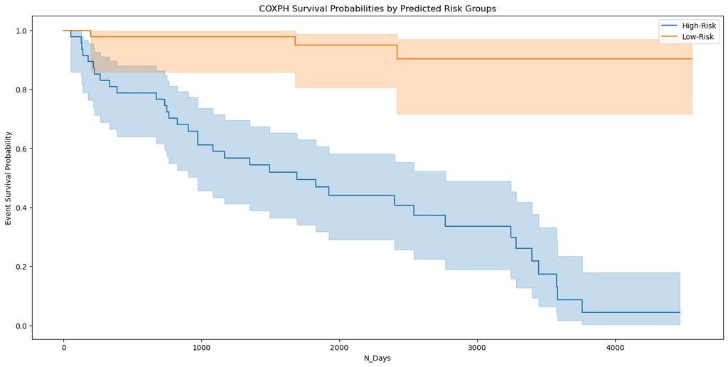

```python
##################################
# Binning the predicted risks
# into dichotomous groups and
# exploring the relationships with
# survival event and duration
##################################
cirrhosis_survival_test.reset_index(drop=True, inplace=True)
kmf = KaplanMeierFitter()
cirrhosis_survival_test['Predicted_Risks_CoxPH'] = optimal_coxph_cirrhosis_survival_y_test_pred
cirrhosis_survival_test['Predicted_RiskGroups_CoxPH'] = risk_groups = pd.qcut(cirrhosis_survival_test['Predicted_Risks_CoxPH'], 2, labels=['Low-Risk', 'High-Risk'])

plt.figure(figsize=(17, 8))
for group in risk_groups.unique():
    group_data = cirrhosis_survival_test[risk_groups == group]
    kmf.fit(group_data['N_Days'], event_observed=group_data['Status'], label=group)
    kmf.plot_survival_function()

plt.title('COXPH Survival Probabilities by Predicted Risk Groups')
plt.xlabel('N_Days')
plt.ylabel('Event Survival Probability')
plt.show()
```

```python
##################################
# Gathering the predictor information
# for 5 test case samples
##################################
test_case_10 = cirrhosis_survival_X_test_preprocessed.iloc[[10, 20, 30, 40, 50]]
display(test_case_10)
```

|  | Age | Bilirubin | Cholesterol | Albumin | Copper | Alk_Phos | SGOT | Tryglicerides | Platelets | Prothrombin | Drug | Sex | Ascites | Hepatomegaly | Spiders | Edema | Stage_1.0 | Stage_2.0 | Stage_3.0 | Stage_4.0 |
| --- | --- | --- | --- | --- | --- | --- | --- | --- | --- | --- | --- | --- | --- | --- | --- | --- | --- | --- | --- | --- |
| 10 | 0.226982 | 1.530100 | 1.302295 | 1.331981 | 1.916467 | -0.477846 | -0.451305 | 2.250260 | 0.201024 | 0.546417 | 1 | 1 | 0 | 1 | 1 | 0 | 0 | 0 | 0 | 1 |
| 20 | -0.147646 | 0.061189 | 0.793618 | -1.158235 | 0.861264 | 0.625621 | 0.319035 | 0.446026 | 1.083875 | -1.508571 | 1 | 1 | 0 | 0 | 0 | 0 | 0 | 0 | 0 | 1 |
| 30 | 0.296370 | -1.283677 | 0.169685 | 3.237777 | -1.008276 | -0.873566 | -0.845549 | -0.351236 | 0.985206 | -0.617113 | 1 | 1 | 0 | 0 | 0 | 0 | 0 | 0 | 1 | 0 |
| 40 | 0.392609 | -0.096645 | -0.486337 | 1.903146 | -0.546292 | -0.247141 | -0.720619 | -0.810790 | -0.000298 | 1.402075 | 0 | 1 | 0 | 1 | 1 | 0 | 0 | 0 | 0 | 1 |
| 50 | -0.813646 | 1.089037 | 0.064451 | 0.212865 | 2.063138 | -0.224432 | 0.074987 | 2.333282 | 0.240640 | -1.125995 | 0 | 1 | 0 | 1 | 1 | 0 | 0 | 0 | 0 | 1 |

```python
##################################
# Gathering the event and duration information
# for 5 test case samples
##################################
print(cirrhosis_survival_y_test_array[[10, 20, 30, 40, 50]])
```

```
[( True, 1827) (False, 1447) (False, 2574) ( True, 3762) (False,  837)]
```

```python
##################################
# Gathering the risk-groups
# for 5 test case samples
##################################
print(cirrhosis_survival_test.loc[[10, 20, 30, 40, 50]][['Predicted_RiskGroups_CoxPH']])
```

```
   Predicted_RiskGroups_CoxPH
10                  High-Risk
20                   Low-Risk
30                   Low-Risk
40                  High-Risk
50                  High-Risk
```

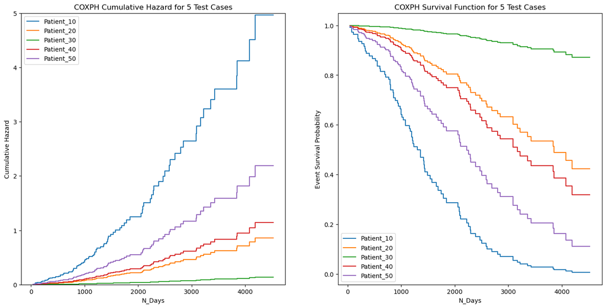

```python
##################################
# Estimating the cumulative hazard
# and survival functions
# for 5 test cases
##################################
test_case = cirrhosis_survival_X_test_preprocessed.iloc[[10, 20, 30, 40, 50]]
test_case_labels = ['Patient_10','Patient_20','Patient_30','Patient_40','Patient_50',]
test_case_cumulative_hazard_function = optimal_coxph_model.predict_cumulative_hazard_function(test_case)
test_case_survival_function = optimal_coxph_model.predict_survival_function(test_case)

fig, ax = plt.subplots(1,2,figsize=(17, 8))
for hazard_prediction, survival_prediction in zip(test_case_cumulative_hazard_function, test_case_survival_function):
    ax[0].step(hazard_prediction.x,hazard_prediction(hazard_prediction.x),where='post')
    ax[1].step(survival_prediction.x,survival_prediction(survival_prediction.x),where='post')
ax[0].set_title('COXPH Cumulative Hazard for 5 Test Cases')
ax[0].set_xlabel('N_Days')
ax[0].set_ylim(0,5)
ax[0].set_ylabel('Cumulative Hazard')
ax[0].legend(test_case_labels, loc="upper left")
ax[1].set_title('COXPH Survival Function for 5 Test Cases')
ax[1].set_xlabel('N_Days')
ax[1].set_ylabel('Event Survival Probability')
ax[1].legend(test_case_labels, loc="lower left")
plt.show()
```

### 1.6.3 Cox Net Survival

[Survival Analysis](https://link.springer.com/book/10.1007/978-1-4419-6646-9/) deals with the analysis of time-to-event data. It focuses on the expected duration of time until one or more events of interest occur, such as death, failure, or relapse. This type of analysis is used to study and model the time until the occurrence of an event, taking into account that the event might not have occurred for all subjects during the study period. Several key aspects of survival analysis include the survival function which refers to the probability that an individual survives longer than a certain time, hazard function which describes the instantaneous rate at which events occur, given no prior event, and censoring pertaining to a condition where the event of interest has not occurred for some subjects during the observation period.

[Right-Censored Survival Data](https://link.springer.com/book/10.1007/978-1-4419-6646-9/) occurs when the event of interest has not happened for some subjects by the end of the study period or the last follow-up time. This type of censoring is common in survival analysis because not all individuals may experience the event before the study ends, or they might drop out or be lost to follow-up. Right-censored data is crucial in survival analysis as it allows the inclusion of all subjects in the analysis, providing more accurate and reliable estimates.

[Survival Models](https://link.springer.com/book/10.1007/978-1-4419-6646-9/) refer to statistical methods used to analyze survival data, accounting for censored observations. These models aim to describe the relationship between survival time and one or more predictor variables, and to estimate the survival function and hazard function. Survival models are essential for understanding the factors that influence time-to-event data, allowing for predictions and comparisons between different groups or treatment effects. They are widely used in clinical trials, reliability engineering, and other areas where time-to-event data is prevalent.

[Cox Net Survival](https://doi.org/10.18637/jss.v039.i05) is a regularized version of the Cox Proportional Hazards model, which incorporates both L1 (Lasso) and L2 (Ridge) penalties. The model is useful when dealing with high-dimensional data where the number of predictors can be larger than the number of observations. The elastic net penalty helps in both variable selection (via L1) and multicollinearity handling (via L2). As a method, it can handle high-dimensional data and perform variable selection. Additionally, it balances between L1 and L2 penalties, offering flexibility in modeling. However, the process requires tuning of penalty parameters, which can be computationally intensive. Additionally, interpretation is more complex due to the regularization terms. Given a dataset with survival times, event indicators, and predictor variables, the algorithm involves defining the penalized partial likelihood function, incorporating both L1 (Lasso) and L2 (Ridge) penalties; application of regularization techniques to estimate the regression coefficients by maximizing the penalized log-partial likelihood; performing cross-validation to select optimal values for the penalty parameters (alpha and l1_ratio); and the calculation of the hazard function and survival function for new data using the estimated regularized coefficients.

1. The [cox net survival model](https://scikit-survival.readthedocs.io/en/stable/api/generated/sksurv.linear_model.CoxnetSurvivalAnalysis.html) from the **sksurv.linear_model** Python library API was implemented.
2. The model implementation used 2 hyperparameters:
   - l1_ratio = ElasticNet mixing parameter made to vary between 0.10, 0.50 and 1.00
   - alpha_min_ratio = minimum alpha of the regularization path made to vary between 0.0001 and 0.01
3. Hyperparameter tuning was conducted using the 5-fold cross-validation method with optimal model performance using the concordance index determined for:
   - l1_ratio = 0.10
   - alpha_min_ratio = 0.01
4. The cross-validated model performance of the optimal model is summarized as follows:
   - **Concordance Index** = 0.8123
5. The apparent model performance of the optimal model is summarized as follows:
   - **Concordance Index** = 0.8472
6. The independent test model performance of the final model is summarized as follows:
   - **Concordance Index** = 0.8717
7. Considerable difference in the apparent and cross-validated model performance observed, indicative of the presence of moderate model overfitting.
8. Survival probability curves obtained from the groups generated by dichotomizing the risk scores demonstrated sufficient differentiation across the entire duration.
9. Hazard and survival probability estimations for 5 sampled cases demonstrated reasonably smooth profiles.

```python
##################################
# Defining a function to perform
# 5-fold cross-validation and hyperparameter tuning
# using the Cox-Net Survival Model
##################################
def cross_validate_coxns_model(X, y, hyperparameters):
    kf = KFold(n_splits=5, shuffle=True, random_state=88888888)
    results = []

    for params in hyperparameters:
        coxns_model = CoxnetSurvivalAnalysis(**params, fit_baseline_model=True)
        fold_results = []

        for train_index, validation_index in kf.split(X):
            X_train, X_validation = X.iloc[train_index], X.iloc[validation_index]
            y_train, y_validation = y[train_index], y[validation_index]

            coxns_model.fit(X_train, y_train)
            pred_survival = coxns_model.predict(X_validation)
            ci = concordance_index_censored(y_validation['Status'], y_validation['N_Days'], pred_survival)[0]
            fold_results.append(ci)

        results.append({
            'Hyperparameters': params,
            'Concordance_Index_Mean': np.mean(fold_results),
            'Concordance_Index_Std': np.std(fold_results)
        })
    return pd.DataFrame(results)
```

```python
##################################
# Defining hyperparameters for tuning
# using the Cox-Net Survival Model
##################################
hyperparameters = [{'l1_ratio': 1.0, 'alpha_min_ratio': 0.0001},
                   {'l1_ratio': 1.0, 'alpha_min_ratio': 0.01},
                   {'l1_ratio': 0.5, 'alpha_min_ratio': 0.0001},
                   {'l1_ratio': 0.5, 'alpha_min_ratio': 0.01},
                   {'l1_ratio': 0.1, 'alpha_min_ratio': 0.0001},
                   {'l1_ratio': 0.1, 'alpha_min_ratio': 0.01}]
```

```python
##################################
# Performing hyperparameter tuning
# through K-fold cross-validation
# using the Cox-Net Survival Model
##################################
cirrhosis_survival_coxns_ht = cross_validate_coxns_model(cirrhosis_survival_X_train_preprocessed,
                                                         cirrhosis_survival_y_train_array,
                                                         hyperparameters)
display(cirrhosis_survival_coxns_ht)
```

|  | Hyperparameters | Concordance_Index_Mean | Concordance_Index_Std |
| --- | --- | --- | --- |
| 0 | {'l1_ratio': 1.0, 'alpha_min_ratio': 0.0001} | 0.806633 | 0.033852 |
| 1 | {'l1_ratio': 1.0, 'alpha_min_ratio': 0.01} | 0.805681 | 0.031412 |
| 2 | {'l1_ratio': 0.5, 'alpha_min_ratio': 0.0001} | 0.806474 | 0.034716 |
| 3 | {'l1_ratio': 0.5, 'alpha_min_ratio': 0.01} | 0.805591 | 0.035271 |
| 4 | {'l1_ratio': 0.1, 'alpha_min_ratio': 0.0001} | 0.805299 | 0.034536 |
| 5 | {'l1_ratio': 0.1, 'alpha_min_ratio': 0.01} | 0.812264 | 0.037303 |

```python
##################################
# Formulating a Cox-Net Survival Model
# with optimal hyperparameters
##################################
optimal_coxns_model = CoxnetSurvivalAnalysis(l1_ratio=0.1, alpha_min_ratio=0.01, fit_baseline_model=True)
optimal_coxns_model.fit(cirrhosis_survival_X_train_preprocessed, cirrhosis_survival_y_train_array)
```

```
CoxnetSurvivalAnalysis(alpha_min_ratio=0.01, fit_baseline_model=True,
                       l1_ratio=0.1)
```

```python
##################################
# Measuring model performance of the
# optimal Cox-Net Survival Model
# on the train set
##################################
optimal_coxns_cirrhosis_survival_y_train_pred = optimal_coxns_model.predict(cirrhosis_survival_X_train_preprocessed)
optimal_coxns_cirrhosis_survival_y_train_ci = concordance_index_censored(cirrhosis_survival_y_train_array['Status'],
                                                                         cirrhosis_survival_y_train_array['N_Days'],
                                                                         optimal_coxns_cirrhosis_survival_y_train_pred)[0]
print(f"Apparent Concordance Index: {optimal_coxns_cirrhosis_survival_y_train_ci}")
```

```
Apparent Concordance Index: 0.8472041612483745
```

```python
##################################
# Measuring model performance of the
# optimal Cox-Net Survival Model
# on the test set
##################################
optimal_coxns_cirrhosis_survival_y_test_pred = optimal_coxns_model.predict(cirrhosis_survival_X_test_preprocessed)
optimal_coxns_cirrhosis_survival_y_test_ci = concordance_index_censored(cirrhosis_survival_y_test_array['Status'],
                                                                        cirrhosis_survival_y_test_array['N_Days'],
                                                                        optimal_coxns_cirrhosis_survival_y_test_pred)[0]
print(f"Test Concordance Index: {optimal_coxns_cirrhosis_survival_y_test_ci}")
```

```
Test Concordance Index: 0.871655328798186
```

```python
##################################
# Gathering the concordance indices
# from the train and tests sets for
# Cox-Net Survival Model
##################################
coxns_set = pd.DataFrame(["Train","Cross-Validation","Test"])
coxns_ci_values = pd.DataFrame([optimal_coxns_cirrhosis_survival_y_train_ci,
                                cirrhosis_survival_coxns_ht.Concordance_Index_Mean.max(),
                                optimal_coxns_cirrhosis_survival_y_test_ci])
coxns_method = pd.DataFrame(["COXNS"]*3)
coxns_summary = pd.concat([coxns_set,
                           coxns_ci_values,
                           coxns_method], axis=1)
coxns_summary.columns = ['Set', 'Concordance.Index', 'Method']
coxns_summary.reset_index(inplace=True, drop=True)
display(coxns_summary)
```

|  | Set | Concordance.Index | Method |
| --- | --- | --- | --- |
| 0 | Train | 0.847204 | COXNS |
| 1 | Cross-Validation | 0.812264 | COXNS |
| 2 | Test | 0.871655 | COXNS |

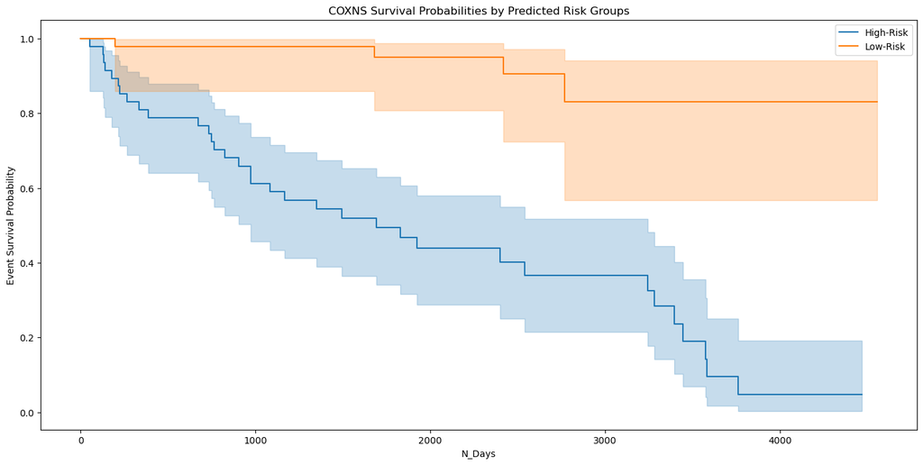

```python
##################################
# Binning the predicted risks
# into dichotomous groups and
# exploring the relationships with
# survival event and duration
##################################
cirrhosis_survival_test.reset_index(drop=True, inplace=True)
kmf = KaplanMeierFitter()
cirrhosis_survival_test['Predicted_Risks_CoxNS'] = optimal_coxns_cirrhosis_survival_y_test_pred
cirrhosis_survival_test['Predicted_RiskGroups_CoxNS'] = risk_groups = pd.qcut(cirrhosis_survival_test['Predicted_Risks_CoxNS'], 2, labels=['Low-Risk', 'High-Risk'])

plt.figure(figsize=(17, 8))
for group in risk_groups.unique():
    group_data = cirrhosis_survival_test[risk_groups == group]
    kmf.fit(group_data['N_Days'], event_observed=group_data['Status'], label=group)
    kmf.plot_survival_function()

plt.title('COXNS Survival Probabilities by Predicted Risk Groups')
plt.xlabel('N_Days')
plt.ylabel('Event Survival Probability')
plt.show()
```

```python
##################################
# Gathering the predictor information
# for 5 test case samples
##################################
test_case_10 = cirrhosis_survival_X_test_preprocessed.iloc[[10, 20, 30, 40, 50]]
display(test_case_10)
```

|  | Age | Bilirubin | Cholesterol | Albumin | Copper | Alk_Phos | SGOT | Tryglicerides | Platelets | Prothrombin | Drug | Sex | Ascites | Hepatomegaly | Spiders | Edema | Stage_1.0 | Stage_2.0 | Stage_3.0 | Stage_4.0 |
| --- | --- | --- | --- | --- | --- | --- | --- | --- | --- | --- | --- | --- | --- | --- | --- | --- | --- | --- | --- | --- |
| 10 | 0.226982 | 1.530100 | 1.302295 | 1.331981 | 1.916467 | -0.477846 | -0.451305 | 2.250260 | 0.201024 | 0.546417 | 1 | 1 | 0 | 1 | 1 | 0 | 0 | 0 | 0 | 1 |
| 20 | -0.147646 | 0.061189 | 0.793618 | -1.158235 | 0.861264 | 0.625621 | 0.319035 | 0.446026 | 1.083875 | -1.508571 | 1 | 1 | 0 | 0 | 0 | 0 | 0 | 0 | 0 | 1 |
| 30 | 0.296370 | -1.283677 | 0.169685 | 3.237777 | -1.008276 | -0.873566 | -0.845549 | -0.351236 | 0.985206 | -0.617113 | 1 | 1 | 0 | 0 | 0 | 0 | 0 | 0 | 1 | 0 |
| 40 | 0.392609 | -0.096645 | -0.486337 | 1.903146 | -0.546292 | -0.247141 | -0.720619 | -0.810790 | -0.000298 | 1.402075 | 0 | 1 | 0 | 1 | 1 | 0 | 0 | 0 | 0 | 1 |
| 50 | -0.813646 | 1.089037 | 0.064451 | 0.212865 | 2.063138 | -0.224432 | 0.074987 | 2.333282 | 0.240640 | -1.125995 | 0 | 1 | 0 | 1 | 1 | 0 | 0 | 0 | 0 | 1 |

```python
##################################
# Gathering the event and duration information
# for 5 test case samples
##################################
print(cirrhosis_survival_y_test_array[[10, 20, 30, 40, 50]])
```

```
[( True, 1827) (False, 1447) (False, 2574) ( True, 3762) (False,  837)]
```

```python
##################################
# Gathering the risk-groups
# for 5 test case samples
##################################
print(cirrhosis_survival_test.loc[[10, 20, 30, 40, 50]][['Predicted_RiskGroups_CoxNS']])
```

```
   Predicted_RiskGroups_CoxNS
10                  High-Risk
20                   Low-Risk
30                   Low-Risk
40                  High-Risk
50                  High-Risk
```

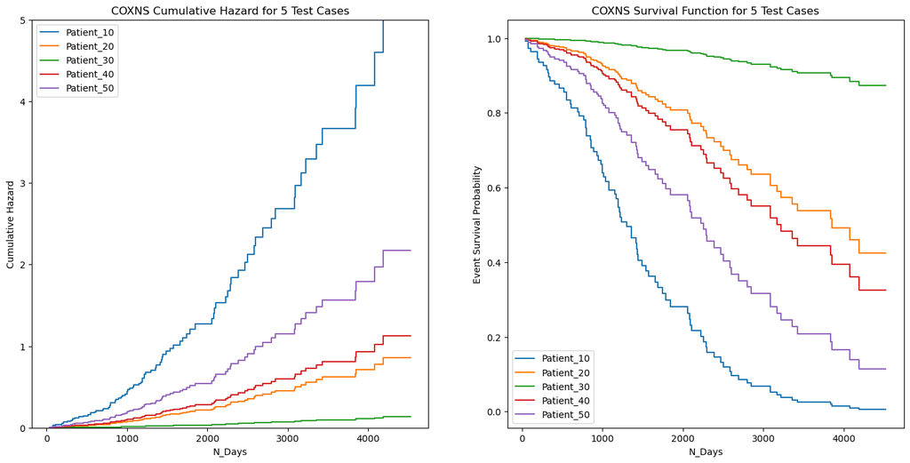

```python
##################################
# Estimating the cumulative hazard
# and survival functions
# for 5 test cases
##################################
test_case = cirrhosis_survival_X_test_preprocessed.iloc[[10, 20, 30, 40, 50]]
test_case_labels = ['Patient_10','Patient_20','Patient_30','Patient_40','Patient_50',]
test_case_cumulative_hazard_function = optimal_coxns_model.predict_cumulative_hazard_function(test_case)
test_case_survival_function = optimal_coxns_model.predict_survival_function(test_case)

fig, ax = plt.subplots(1,2,figsize=(17, 8))
for hazard_prediction, survival_prediction in zip(test_case_cumulative_hazard_function, test_case_survival_function):
    ax[0].step(hazard_prediction.x,hazard_prediction(hazard_prediction.x),where='post')
    ax[1].step(survival_prediction.x,survival_prediction(survival_prediction.x),where='post')
ax[0].set_title('COXNS Cumulative Hazard for 5 Test Cases')
ax[0].set_xlabel('N_Days')
ax[0].set_ylim(0,5)
ax[0].set_ylabel('Cumulative Hazard')
ax[0].legend(test_case_labels, loc="upper left")
ax[1].set_title('COXNS Survival Function for 5 Test Cases')
ax[1].set_xlabel('N_Days')
ax[1].set_ylabel('Event Survival Probability')
ax[1].legend(test_case_labels, loc="lower left")
plt.show()
```

### 1.6.4 Survival Tree

[Survival Analysis](https://link.springer.com/book/10.1007/978-1-4419-6646-9/) deals with the analysis of time-to-event data. It focuses on the expected duration of time until one or more events of interest occur, such as death, failure, or relapse. This type of analysis is used to study and model the time until the occurrence of an event, taking into account that the event might not have occurred for all subjects during the study period. Several key aspects of survival analysis include the survival function which refers to the probability that an individual survives longer than a certain time, hazard function which describes the instantaneous rate at which events occur, given no prior event, and censoring pertaining to a condition where the event of interest has not occurred for some subjects during the observation period.

[Right-Censored Survival Data](https://link.springer.com/book/10.1007/978-1-4419-6646-9/) occurs when the event of interest has not happened for some subjects by the end of the study period or the last follow-up time. This type of censoring is common in survival analysis because not all individuals may experience the event before the study ends, or they might drop out or be lost to follow-up. Right-censored data is crucial in survival analysis as it allows the inclusion of all subjects in the analysis, providing more accurate and reliable estimates.

[Survival Models](https://link.springer.com/book/10.1007/978-1-4419-6646-9/) refer to statistical methods used to analyze survival data, accounting for censored observations. These models aim to describe the relationship between survival time and one or more predictor variables, and to estimate the survival function and hazard function. Survival models are essential for understanding the factors that influence time-to-event data, allowing for predictions and comparisons between different groups or treatment effects. They are widely used in clinical trials, reliability engineering, and other areas where time-to-event data is prevalent.

[Survival Trees](https://www.tandfonline.com/doi/abs/10.1080/01621459.1993.10476296) are non-parametric models that partition the data into subgroups (nodes) based on the values of predictor variables, creating a tree-like structure. The tree is built by recursively splitting the data at nodes where the differences in survival times between subgroups are maximized. Each terminal node represents a different survival function. The method have no assumptions about the underlying distribution of survival times, can capture interactions between variables naturally and applies an interpretable visual representation. However, the process can be prone to overfitting, especially with small datasets, and may be less accurate compared to ensemble methods like Random Survival Forest. Given a dataset with survival times, event indicators, and predictor variables, the algorithm involves recursively splitting the data at nodes to maximize the differences in survival times between subgroups with the splitting criteria often involving statistical tests (e.g., log-rank test); choosing the best predictor variable and split point at each node that maximizes the separation of survival times; continuously splitting until stopping criteria are met (e.g., minimum number of observations in a node, maximum tree depth); and estimating the survival function based on the survival times of the observations at each terminal node.

```python
##################################
# Defining a function to perform
# 5-fold cross-validation and hyperparameter tuning
# using the Survival Tree Model
##################################
def cross_validate_stree_model(X, y, hyperparameters):
    kf = KFold(n_splits=5, shuffle=True, random_state=88888888)
    results = []

    for params in hyperparameters:
        stree_model = SurvivalTree(**params, random_state=88888888)
        fold_results = []

        for train_index, validation_index in kf.split(X):
            X_train, X_validation = X.iloc[train_index], X.iloc[validation_index]
            y_train, y_validation = y[train_index], y[validation_index]

            stree_model.fit(X_train, y_train)
            pred_survival = stree_model.predict(X_validation)
            ci = concordance_index_censored(y_validation['Status'], y_validation['N_Days'], pred_survival)[0]
            fold_results.append(ci)

        results.append({
            'Hyperparameters': params,
            'Concordance_Index_Mean': np.mean(fold_results),
            'Concordance_Index_Std': np.std(fold_results)
        })
    return pd.DataFrame(results)
```

```python
##################################
# Defining hyperparameters for tuning
# using the Survival Tree Model
##################################
hyperparameters = [{'min_samples_split': 30, 'min_samples_leaf': 10},
                   {'min_samples_split': 30, 'min_samples_leaf': 5},
                   {'min_samples_split': 20, 'min_samples_leaf': 10},
                   {'min_samples_split': 20, 'min_samples_leaf': 5}]
```

```python
##################################
# Performing hyperparameter tuning
# through K-fold cross-validation
# using the Survival Tree Model
##################################
cirrhosis_survival_stree_ht = cross_validate_stree_model(cirrhosis_survival_X_train_preprocessed,
                                                         cirrhosis_survival_y_train_array,
                                                         hyperparameters)
display(cirrhosis_survival_stree_ht)
```

|  | Hyperparameters | Concordance_Index_Mean | Concordance_Index_Std |
| --- | --- | --- | --- |
| 0 | {'min_samples_split': 30, 'min_samples_leaf': 10} | 0.772549 | 0.034646 |
| 1 | {'min_samples_split': 30, 'min_samples_leaf': 5} | 0.793183 | 0.007672 |
| 2 | {'min_samples_split': 20, 'min_samples_leaf': 10} | 0.786565 | 0.032803 |
| 3 | {'min_samples_split': 20, 'min_samples_leaf': 5} | 0.791438 | 0.024420 |

```python
##################################
# Formulating a Survival Tree Model
# with optimal hyperparameters
##################################
optimal_stree_model = SurvivalTree(min_samples_split=30, min_samples_leaf=5, random_state=88888888)
optimal_stree_model.fit(cirrhosis_survival_X_train_preprocessed, cirrhosis_survival_y_train_array)
```

```
SurvivalTree(min_samples_leaf=5, min_samples_split=30, random_state=88888888)
```

```python
##################################
# Measuring model performance of the
# optimal Survival Tree Model
# on the train set
##################################
optimal_stree_cirrhosis_survival_y_train_pred = optimal_stree_model.predict(cirrhosis_survival_X_train_preprocessed)
optimal_stree_cirrhosis_survival_y_train_ci = concordance_index_censored(cirrhosis_survival_y_train_array['Status'],
                                                                        cirrhosis_survival_y_train_array['N_Days'],
                                                                        optimal_stree_cirrhosis_survival_y_train_pred)[0]
print(f"Apparent Concordance Index: {optimal_stree_cirrhosis_survival_y_train_ci}")
```

```
Apparent Concordance Index: 0.8646781534460338
```

```python
##################################
# Measuring model performance of the
# optimal Survival Tree Model
# on the test set
##################################
optimal_stree_cirrhosis_survival_y_test_pred = optimal_stree_model.predict(cirrhosis_survival_X_test_preprocessed)
optimal_stree_cirrhosis_survival_y_test_ci = concordance_index_censored(cirrhosis_survival_y_test_array['Status'],
                                                                       cirrhosis_survival_y_test_array['N_Days'],
                                                                       optimal_stree_cirrhosis_survival_y_test_pred)[0]
print(f"Test Concordance Index: {optimal_stree_cirrhosis_survival_y_test_ci}")
```

```
Test Concordance Index: 0.8174603174603174
```

```python
##################################
# Gathering the concordance indices
# from the train and tests sets for
# Survival Tree Model
##################################
stree_set = pd.DataFrame(["Train","Cross-Validation","Test"])
stree_ci_values = pd.DataFrame([optimal_stree_cirrhosis_survival_y_train_ci,
                                cirrhosis_survival_stree_ht.Concordance_Index_Mean.max(),
                                optimal_stree_cirrhosis_survival_y_test_ci])
stree_method = pd.DataFrame(["STREE"]*3)
stree_summary = pd.concat([stree_set,
                           stree_ci_values,
                           stree_method], axis=1)
stree_summary.columns = ['Set', 'Concordance.Index', 'Method']
stree_summary.reset_index(inplace=True, drop=True)
display(stree_summary)
```

|  | Set | Concordance.Index | Method |
| --- | --- | --- | --- |
| 0 | Train | 0.864678 | STREE |
| 1 | Cross-Validation | 0.793183 | STREE |
| 2 | Test | 0.817460 | STREE |

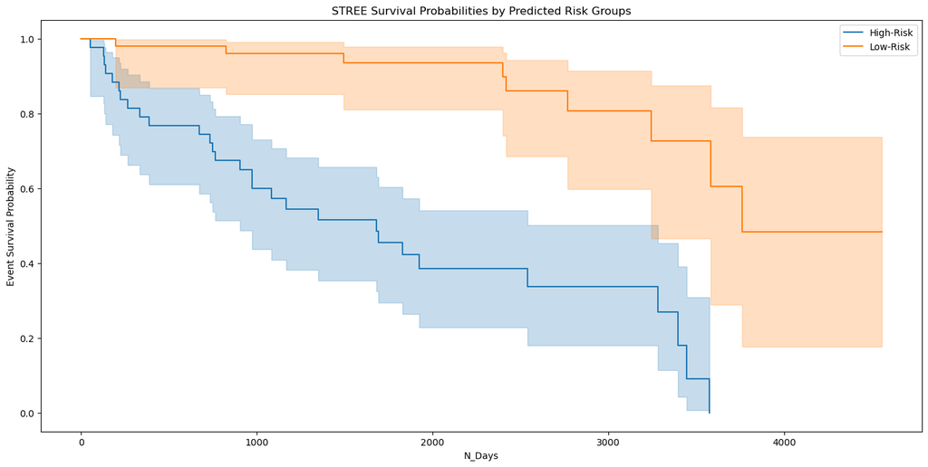

```python
##################################
# Binning the predicted risks
# into dichotomous groups and
# exploring the relationships with
# survival event and duration
##################################
cirrhosis_survival_test.reset_index(drop=True, inplace=True)
kmf = KaplanMeierFitter()
cirrhosis_survival_test['Predicted_Risks_STree'] = optimal_stree_cirrhosis_survival_y_test_pred
cirrhosis_survival_test['Predicted_RiskGroups_STree'] = risk_groups = pd.qcut(cirrhosis_survival_test['Predicted_Risks_STree'], 2, labels=['Low-Risk', 'High-Risk'])

plt.figure(figsize=(17, 8))
for group in risk_groups.unique():
    group_data = cirrhosis_survival_test[risk_groups == group]
    kmf.fit(group_data['N_Days'], event_observed=group_data['Status'], label=group)
    kmf.plot_survival_function()

plt.title('STREE Survival Probabilities by Predicted Risk Groups')
plt.xlabel('N_Days')
plt.ylabel('Event Survival Probability')
plt.show()
```

```python
##################################
# Gathering the predictor information
# for 5 test case samples
##################################
test_case_10 = cirrhosis_survival_X_test_preprocessed.iloc[[10, 20, 30, 40, 50]]
display(test_case_10)
```

|  | Age | Bilirubin | Cholesterol | Albumin | Copper | Alk_Phos | SGOT | Tryglicerides | Platelets | Prothrombin | Drug | Sex | Ascites | Hepatomegaly | Spiders | Edema | Stage_1.0 | Stage_2.0 | Stage_3.0 | Stage_4.0 |
| --- | --- | --- | --- | --- | --- | --- | --- | --- | --- | --- | --- | --- | --- | --- | --- | --- | --- | --- | --- | --- |
| 10 | 0.226982 | 1.530100 | 1.302295 | 1.331981 | 1.916467 | -0.477846 | -0.451305 | 2.250260 | 0.201024 | 0.546417 | 1 | 1 | 0 | 1 | 1 | 0 | 0 | 0 | 0 | 1 |
| 20 | -0.147646 | 0.061189 | 0.793618 | -1.158235 | 0.861264 | 0.625621 | 0.319035 | 0.446026 | 1.083875 | -1.508571 | 1 | 1 | 0 | 0 | 0 | 0 | 0 | 0 | 0 | 1 |
| 30 | 0.296370 | -1.283677 | 0.169685 | 3.237777 | -1.008276 | -0.873566 | -0.845549 | -0.351236 | 0.985206 | -0.617113 | 1 | 1 | 0 | 0 | 0 | 0 | 0 | 0 | 1 | 0 |
| 40 | 0.392609 | -0.096645 | -0.486337 | 1.903146 | -0.546292 | -0.247141 | -0.720619 | -0.810790 | -0.000298 | 1.402075 | 0 | 1 | 0 | 1 | 1 | 0 | 0 | 0 | 0 | 1 |
| 50 | -0.813646 | 1.089037 | 0.064451 | 0.212865 | 2.063138 | -0.224432 | 0.074987 | 2.333282 | 0.240640 | -1.125995 | 0 | 1 | 0 | 1 | 1 | 0 | 0 | 0 | 0 | 1 |

```python
##################################
# Gathering the event and duration information
# for 5 test case samples
##################################
print(cirrhosis_survival_y_test_array[[10, 20, 30, 40, 50]])
```

```
[( True, 1827) (False, 1447) (False, 2574) ( True, 3762) (False,  837)]
```

```python
##################################
# Gathering the risk-groups
# for 5 test case samples
##################################
print(cirrhosis_survival_test.loc[[10, 20, 30, 40, 50]][['Predicted_RiskGroups_STree']])
```

```
   Predicted_RiskGroups_STree
10                  High-Risk
20                   Low-Risk
30                   Low-Risk
40                   Low-Risk
50                  High-Risk
```

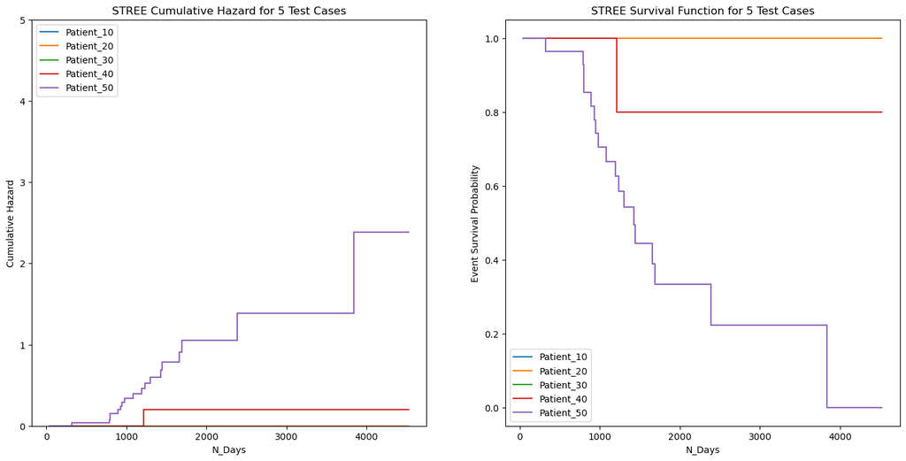

```python
##################################
# Estimating the cumulative hazard
# and survival functions
# for 5 test cases
##################################
test_case = cirrhosis_survival_X_test_preprocessed.iloc[[10, 20, 30, 40, 50]]
test_case_labels = ['Patient_10','Patient_20','Patient_30','Patient_40','Patient_50',]
test_case_cumulative_hazard_function = optimal_stree_model.predict_cumulative_hazard_function(test_case)
test_case_survival_function = optimal_stree_model.predict_survival_function(test_case)

fig, ax = plt.subplots(1,2,figsize=(17, 8))
for hazard_prediction, survival_prediction in zip(test_case_cumulative_hazard_function, test_case_survival_function):
    ax[0].step(hazard_prediction.x,hazard_prediction(hazard_prediction.x),where='post')
    ax[1].step(survival_prediction.x,survival_prediction(survival_prediction.x),where='post')
ax[0].set_title('STREE Cumulative Hazard for 5 Test Cases')
ax[0].set_xlabel('N_Days')
ax[0].set_ylim(0,5)
ax[0].set_ylabel('Cumulative Hazard')
ax[0].legend(test_case_labels, loc="upper left")
ax[1].set_title('STREE Survival Function for 5 Test Cases')
ax[1].set_xlabel('N_Days')
ax[1].set_ylabel('Event Survival Probability')
ax[1].legend(test_case_labels, loc="lower left")
plt.show()
```

### 1.6.5 Random Survival Forest

[Survival Analysis](https://link.springer.com/book/10.1007/978-1-4419-6646-9/) deals with the analysis of time-to-event data. It focuses on the expected duration of time until one or more events of interest occur, such as death, failure, or relapse. This type of analysis is used to study and model the time until the occurrence of an event, taking into account that the event might not have occurred for all subjects during the study period. Several key aspects of survival analysis include the survival function which refers to the probability that an individual survives longer than a certain time, hazard function which describes the instantaneous rate at which events occur, given no prior event, and censoring pertaining to a condition where the event of interest has not occurred for some subjects during the observation period.

[Right-Censored Survival Data](https://link.springer.com/book/10.1007/978-1-4419-6646-9/) occurs when the event of interest has not happened for some subjects by the end of the study period or the last follow-up time. This type of censoring is common in survival analysis because not all individuals may experience the event before the study ends, or they might drop out or be lost to follow-up. Right-censored data is crucial in survival analysis as it allows the inclusion of all subjects in the analysis, providing more accurate and reliable estimates.

[Survival Models](https://link.springer.com/book/10.1007/978-1-4419-6646-9/) refer to statistical methods used to analyze survival data, accounting for censored observations. These models aim to describe the relationship between survival time and one or more predictor variables, and to estimate the survival function and hazard function. Survival models are essential for understanding the factors that influence time-to-event data, allowing for predictions and comparisons between different groups or treatment effects. They are widely used in clinical trials, reliability engineering, and other areas where time-to-event data is prevalent.

[Random Survival Forest](https://projecteuclid.org/journals/annals-of-applied-statistics/volume-2/issue-3/Random-survival-forests/10.1214/08-AOAS169.full) is an ensemble method that builds multiple survival trees and averages their predictions. The model combines the predictions of multiple survival trees, each built on a bootstrap sample of the data and a random subset of predictors. It uses the concept of ensemble learning to improve predictive accuracy and robustness. As a method, it handles high-dimensional data and complex interactions between variables well; can be more accurate and robust than a single survival tree; and provides measures of variable importance. However, the process can be bomputationally intensive due to the need to build multiple trees, and may be less interpretable than single trees or parametric models like the Cox model. Given a dataset with survival times, event indicators, and predictor variables, the algorithm involves generating multiple bootstrap samples from the original dataset; building a survival tree by recursively splitting the data at nodes using a random subset of predictor variables for each bootstrap sample; combining the predictions of all survival trees to form the random survival forest and averaging the survival functions predicted by all trees in the forest to obtain the final survival function for new data.

```python
##################################
# Defining a function to perform
# 5-fold cross-validation and hyperparameter tuning
# using the Random Survival Forest Model
##################################
def cross_validate_rsf_model(X, y, hyperparameters):
    kf = KFold(n_splits=5, shuffle=True, random_state=88888888)
    results = []

    for params in hyperparameters:
        rsf_model = RandomSurvivalForest(**params, random_state=88888888)
        fold_results = []

        for train_index, validation_index in kf.split(X):
            X_train, X_validation = X.iloc[train_index], X.iloc[validation_index]
            y_train, y_validation = y[train_index], y[validation_index]

            rsf_model.fit(X_train, y_train)
            pred_survival = rsf_model.predict(X_validation)
            ci = concordance_index_censored(y_validation['Status'], y_validation['N_Days'], pred_survival)[0]
            fold_results.append(ci)

        results.append({
            'Hyperparameters': params,
            'Concordance_Index_Mean': np.mean(fold_results),
            'Concordance_Index_Std': np.std(fold_results)
        })
    return pd.DataFrame(results)
```

```python
##################################
# Defining hyperparameters for tuning
# using the Random Survival Forest Model
##################################
hyperparameters = [{'n_estimators': 100, 'min_samples_split': 20},
                   {'n_estimators': 100, 'min_samples_split': 10},
                   {'n_estimators': 200, 'min_samples_split': 20},
                   {'n_estimators': 200, 'min_samples_split': 10},
                   {'n_estimators': 300, 'min_samples_split': 20},
                   {'n_estimators': 300, 'min_samples_split': 10}]
```

```python
##################################
# Performing hyperparameter tuning
# through K-fold cross-validation
# using the Random Survival Forest Model
##################################
cirrhosis_survival_rsf_ht = cross_validate_rsf_model(cirrhosis_survival_X_train_preprocessed,
                                                     cirrhosis_survival_y_train_array,
                                                     hyperparameters)
display(cirrhosis_survival_rsf_ht)
```

|  | Hyperparameters | Concordance_Index_Mean | Concordance_Index_Std |
| --- | --- | --- | --- |
| 0 | {'n_estimators': 100, 'min_samples_split': 20} | 0.815665 | 0.050443 |
| 1 | {'n_estimators': 100, 'min_samples_split': 10} | 0.821493 | 0.047560 |
| 2 | {'n_estimators': 200, 'min_samples_split': 20} | 0.810443 | 0.055901 |
| 3 | {'n_estimators': 200, 'min_samples_split': 10} | 0.818115 | 0.052540 |
| 4 | {'n_estimators': 300, 'min_samples_split': 20} | 0.813252 | 0.052448 |
| 5 | {'n_estimators': 300, 'min_samples_split': 10} | 0.819385 | 0.047949 |

```python
##################################
# Formulating a Random Survival Forest Model
# with optimal hyperparameters
##################################
optimal_rsf_model = RandomSurvivalForest(n_estimators=100, min_samples_split=10, random_state=88888888)
optimal_rsf_model.fit(cirrhosis_survival_X_train_preprocessed, cirrhosis_survival_y_train_array)
```

```
RandomSurvivalForest(min_samples_split=10, random_state=88888888)
```

```python
##################################
# Measuring model performance of the
# optimal Random Survival Forest Model
# on the train set
##################################
optimal_rsf_cirrhosis_survival_y_train_pred = optimal_rsf_model.predict(cirrhosis_survival_X_train_preprocessed)
optimal_rsf_cirrhosis_survival_y_train_ci = concordance_index_censored(cirrhosis_survival_y_train_array['Status'],
                                                                       cirrhosis_survival_y_train_array['N_Days'],
                                                                       optimal_rsf_cirrhosis_survival_y_train_pred)[0]
print(f"Apparent Concordance Index: {optimal_rsf_cirrhosis_survival_y_train_ci}")
```

```
Apparent Concordance Index: 0.9153120936280884
```

```python
##################################
# Measuring model performance of the
# optimal Random Survival Forest Model
# on the test set
##################################
optimal_rsf_cirrhosis_survival_y_test_pred = optimal_rsf_model.predict(cirrhosis_survival_X_test_preprocessed)
optimal_rsf_cirrhosis_survival_y_test_ci = concordance_index_censored(cirrhosis_survival_y_test_array['Status'],
                                                                      cirrhosis_survival_y_test_array['N_Days'],
                                                                      optimal_rsf_cirrhosis_survival_y_test_pred)[0]
print(f"Test Concordance Index: {optimal_rsf_cirrhosis_survival_y_test_ci}")
```

```
Test Concordance Index: 0.8761904761904762
```

```python
##################################
# Gathering the concordance indices
# from the train and tests sets for
# Random Survival Forest Model
##################################
rsf_set = pd.DataFrame(["Train","Cross-Validation","Test"])
rsf_ci_values = pd.DataFrame([optimal_rsf_cirrhosis_survival_y_train_ci,
                              cirrhosis_survival_rsf_ht.Concordance_Index_Mean.max(),
                                optimal_rsf_cirrhosis_survival_y_test_ci])
rsf_method = pd.DataFrame(["RSF"]*3)
rsf_summary = pd.concat([rsf_set,
                           rsf_ci_values,
                           rsf_method], axis=1)
rsf_summary.columns = ['Set', 'Concordance.Index', 'Method']
rsf_summary.reset_index(inplace=True, drop=True)
display(rsf_summary)
```

|  | Set | Concordance.Index | Method |
| --- | --- | --- | --- |
| 0 | Train | 0.915312 | RSF |
| 1 | Cross-Validation | 0.821493 | RSF |
| 2 | Test | 0.876190 | RSF |

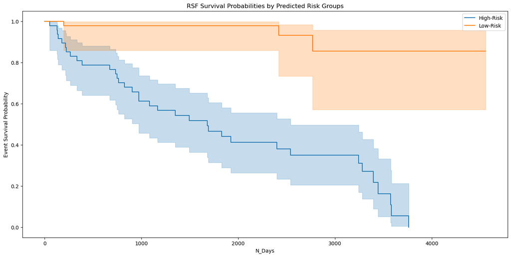

```python
##################################
# Binning the predicted risks
# into dichotomous groups and
# exploring the relationships with
# survival event and duration
##################################
cirrhosis_survival_test.reset_index(drop=True, inplace=True)
kmf = KaplanMeierFitter()
cirrhosis_survival_test['Predicted_Risks_RSF'] = optimal_rsf_cirrhosis_survival_y_test_pred
cirrhosis_survival_test['Predicted_RiskGroups_RSF'] = risk_groups = pd.qcut(cirrhosis_survival_test['Predicted_Risks_RSF'], 2, labels=['Low-Risk', 'High-Risk'])

plt.figure(figsize=(17, 8))
for group in risk_groups.unique():
    group_data = cirrhosis_survival_test[risk_groups == group]
    kmf.fit(group_data['N_Days'], event_observed=group_data['Status'], label=group)
    kmf.plot_survival_function()

plt.title('RSF Survival Probabilities by Predicted Risk Groups')
plt.xlabel('N_Days')
plt.ylabel('Event Survival Probability')
plt.show()
```

```python
##################################
# Gathering the predictor information
# for 5 test case samples
##################################
test_case_10 = cirrhosis_survival_X_test_preprocessed.iloc[[10, 20, 30, 40, 50]]
display(test_case_10)
```

|  | Age | Bilirubin | Cholesterol | Albumin | Copper | Alk_Phos | SGOT | Tryglicerides | Platelets | Prothrombin | Drug | Sex | Ascites | Hepatomegaly | Spiders | Edema | Stage_1.0 | Stage_2.0 | Stage_3.0 | Stage_4.0 |
| --- | --- | --- | --- | --- | --- | --- | --- | --- | --- | --- | --- | --- | --- | --- | --- | --- | --- | --- | --- | --- |
| 10 | 0.226982 | 1.530100 | 1.302295 | 1.331981 | 1.916467 | -0.477846 | -0.451305 | 2.250260 | 0.201024 | 0.546417 | 1 | 1 | 0 | 1 | 1 | 0 | 0 | 0 | 0 | 1 |
| 20 | -0.147646 | 0.061189 | 0.793618 | -1.158235 | 0.861264 | 0.625621 | 0.319035 | 0.446026 | 1.083875 | -1.508571 | 1 | 1 | 0 | 0 | 0 | 0 | 0 | 0 | 0 | 1 |
| 30 | 0.296370 | -1.283677 | 0.169685 | 3.237777 | -1.008276 | -0.873566 | -0.845549 | -0.351236 | 0.985206 | -0.617113 | 1 | 1 | 0 | 0 | 0 | 0 | 0 | 0 | 1 | 0 |
| 40 | 0.392609 | -0.096645 | -0.486337 | 1.903146 | -0.546292 | -0.247141 | -0.720619 | -0.810790 | -0.000298 | 1.402075 | 0 | 1 | 0 | 1 | 1 | 0 | 0 | 0 | 0 | 1 |
| 50 | -0.813646 | 1.089037 | 0.064451 | 0.212865 | 2.063138 | -0.224432 | 0.074987 | 2.333282 | 0.240640 | -1.125995 | 0 | 1 | 0 | 1 | 1 | 0 | 0 | 0 | 0 | 1 |

```python
##################################
# Gathering the event and duration information
# for 5 test case samples
##################################
print(cirrhosis_survival_y_test_array[[10, 20, 30, 40, 50]])
```

```
[( True, 1827) (False, 1447) (False, 2574) ( True, 3762) (False,  837)]
```

```python
##################################
# Gathering the risk-groups
# for 5 test case samples
##################################
print(cirrhosis_survival_test.loc[[10, 20, 30, 40, 50]][['Predicted_RiskGroups_RSF']])
```

```
   Predicted_RiskGroups_RSF
10                High-Risk
20                High-Risk
30                 Low-Risk
40                High-Risk
50                High-Risk
```

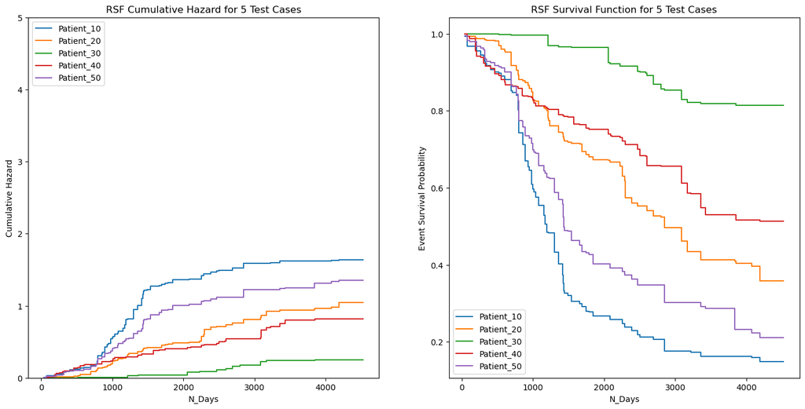

```python
##################################
# Estimating the cumulative hazard
# and survival functions
# for 5 test cases
##################################
test_case = cirrhosis_survival_X_test_preprocessed.iloc[[10, 20, 30, 40, 50]]
test_case_labels = ['Patient_10','Patient_20','Patient_30','Patient_40','Patient_50',]
test_case_cumulative_hazard_function = optimal_rsf_model.predict_cumulative_hazard_function(test_case)
test_case_survival_function = optimal_rsf_model.predict_survival_function(test_case)

fig, ax = plt.subplots(1,2,figsize=(17, 8))
for hazard_prediction, survival_prediction in zip(test_case_cumulative_hazard_function, test_case_survival_function):
    ax[0].step(hazard_prediction.x,hazard_prediction(hazard_prediction.x),where='post')
    ax[1].step(survival_prediction.x,survival_prediction(survival_prediction.x),where='post')
ax[0].set_title('RSF Cumulative Hazard for 5 Test Cases')
ax[0].set_xlabel('N_Days')
ax[0].set_ylim(0,5)
ax[0].set_ylabel('Cumulative Hazard')
ax[0].legend(test_case_labels, loc="upper left")
ax[1].set_title('RSF Survival Function for 5 Test Cases')
ax[1].set_xlabel('N_Days')
ax[1].set_ylabel('Event Survival Probability')
ax[1].legend(test_case_labels, loc="lower left")
plt.show()
```

### 1.6.6 Gradient Boosted Survival

[Survival Analysis](https://link.springer.com/book/10.1007/978-1-4419-6646-9/) deals with the analysis of time-to-event data. It focuses on the expected duration of time until one or more events of interest occur, such as death, failure, or relapse. This type of analysis is used to study and model the time until the occurrence of an event, taking into account that the event might not have occurred for all subjects during the study period. Several key aspects of survival analysis include the survival function which refers to the probability that an individual survives longer than a certain time, hazard function which describes the instantaneous rate at which events occur, given no prior event, and censoring pertaining to a condition where the event of interest has not occurred for some subjects during the observation period.

[Right-Censored Survival Data](https://link.springer.com/book/10.1007/978-1-4419-6646-9/) occurs when the event of interest has not happened for some subjects by the end of the study period or the last follow-up time. This type of censoring is common in survival analysis because not all individuals may experience the event before the study ends, or they might drop out or be lost to follow-up. Right-censored data is crucial in survival analysis as it allows the inclusion of all subjects in the analysis, providing more accurate and reliable estimates.

[Survival Models](https://link.springer.com/book/10.1007/978-1-4419-6646-9/) refer to statistical methods used to analyze survival data, accounting for censored observations. These models aim to describe the relationship between survival time and one or more predictor variables, and to estimate the survival function and hazard function. Survival models are essential for understanding the factors that influence time-to-event data, allowing for predictions and comparisons between different groups or treatment effects. They are widely used in clinical trials, reliability engineering, and other areas where time-to-event data is prevalent.

[Gradient Boosted Survival](https://projecteuclid.org/journals/annals-of-statistics/volume-29/issue-5/Greedy-function-approximation-A-gradient-boosting-machine/10.1214/aos/1013203451.full) is an ensemble technique that builds a series of survival trees, where each tree tries to correct the errors of the previous one. The model uses boosting, a sequential technique where each new tree is fit to the residuals of the combined previous trees, and combines the predictions of all the trees to produce a final prediction. As a method, it has high predictive accuracy, the ability to model complex relationships, and reduces bias and variance compared to single-tree models. However, the process can even be more computationally intensive than Random Survival Forest, requires careful tuning of multiple hyperparameters, and makes interpretation challenging due to the complex nature of the model. Given a dataset with survival times, event indicators, and predictor variables, the algorithm involves starting with an initial prediction (often the median survival time or a simple model); calculating the residuals (errors) of the current model's predictions; fitting a survival tree to the residuals to learn the errors made by the current model; updating the current model by adding the new tree weighted by a learning rate parameter; repeating previous steps for a fixed number of iterations or until convergence; and summing the predictions of all trees in the sequence to obtain the final survival function for new data.

```python
##################################
# Defining a function to perform
# 5-fold cross-validation and hyperparameter tuning
# using the Gradient Boosted Survival Model
##################################
def cross_validate_gbs_model(X, y, hyperparameters):
    kf = KFold(n_splits=5, shuffle=True, random_state=88888888)
    results = []

    for params in hyperparameters:
        gbs_model = GradientBoostingSurvivalAnalysis(**params, random_state=88888888)
        fold_results = []

        for train_index, validation_index in kf.split(X):
            X_train, X_validation = X.iloc[train_index], X.iloc[validation_index]
            y_train, y_validation = y[train_index], y[validation_index]

            gbs_model.fit(X_train, y_train)
            pred_survival = gbs_model.predict(X_validation)
            ci = concordance_index_censored(y_validation['Status'], y_validation['N_Days'], pred_survival)[0]
            fold_results.append(ci)

        results.append({
            'Hyperparameters': params,
            'Concordance_Index_Mean': np.mean(fold_results),
            'Concordance_Index_Std': np.std(fold_results)
        })
    return pd.DataFrame(results)
```

```python
##################################
# Defining hyperparameters for tuning
# using the Gradient Boosted Survival Model
##################################
hyperparameters = [{'n_estimators': 100, 'learning_rate': 0.10},
                   {'n_estimators': 100, 'learning_rate': 0.05},
                   {'n_estimators': 200, 'learning_rate': 0.10},
                   {'n_estimators': 200, 'learning_rate': 0.05},
                   {'n_estimators': 300, 'learning_rate': 0.10},
                   {'n_estimators': 300, 'learning_rate': 0.05}]
```

```python
##################################
# Performing hyperparameter tuning
# through K-fold cross-validation
# using the Gradient Boosted Survival Model
##################################
cirrhosis_survival_gbs_ht = cross_validate_gbs_model(cirrhosis_survival_X_train_preprocessed,
                                                     cirrhosis_survival_y_train_array,
                                                     hyperparameters)
display(cirrhosis_survival_gbs_ht)
```

|  | Hyperparameters | Concordance_Index_Mean | Concordance_Index_Std |
| --- | --- | --- | --- |
| 0 | {'n_estimators': 100, 'learning_rate': 0.1} | 0.800822 | 0.038410 |
| 1 | {'n_estimators': 100, 'learning_rate': 0.05} | 0.805171 | 0.039901 |
| 2 | {'n_estimators': 200, 'learning_rate': 0.1} | 0.800767 | 0.037214 |
| 3 | {'n_estimators': 200, 'learning_rate': 0.05} | 0.799043 | 0.037200 |
| 4 | {'n_estimators': 300, 'learning_rate': 0.1} | 0.800466 | 0.032817 |
| 5 | {'n_estimators': 300, 'learning_rate': 0.05} | 0.798193 | 0.035516 |

```python
##################################
# Formulating a Gradient Boosted Survival Model
# with optimal hyperparameters
##################################
optimal_gbs_model = GradientBoostingSurvivalAnalysis(n_estimators=100, learning_rate=0.05, random_state=88888888)
optimal_gbs_model.fit(cirrhosis_survival_X_train_preprocessed, cirrhosis_survival_y_train_array)
```

```
GradientBoostingSurvivalAnalysis(learning_rate=0.05, random_state=88888888)
```

```python
##################################
# Measuring model performance of the
# optimal Gradient Boosted Survival Model
# on the train set
##################################
optimal_gbs_cirrhosis_survival_y_train_pred = optimal_gbs_model.predict(cirrhosis_survival_X_train_preprocessed)
optimal_gbs_cirrhosis_survival_y_train_ci = concordance_index_censored(cirrhosis_survival_y_train_array['Status'],
                                                                       cirrhosis_survival_y_train_array['N_Days'],
                                                                       optimal_gbs_cirrhosis_survival_y_train_pred)[0]
print(f"Apparent Concordance Index: {optimal_gbs_cirrhosis_survival_y_train_ci}")
```

```
Apparent Concordance Index: 0.9280721716514955
```

```python
##################################
# Measuring model performance of the
# optimal Gradient Boosted Survival Model
# on the test set
##################################
optimal_gbs_cirrhosis_survival_y_test_pred = optimal_gbs_model.predict(cirrhosis_survival_X_test_preprocessed)
optimal_gbs_cirrhosis_survival_y_test_ci = concordance_index_censored(cirrhosis_survival_y_test_array['Status'],
                                                                      cirrhosis_survival_y_test_array['N_Days'],
                                                                      optimal_gbs_cirrhosis_survival_y_test_pred)[0]
print(f"Test Concordance Index: {optimal_gbs_cirrhosis_survival_y_test_ci}")
```

```
Test Concordance Index: 0.8657596371882086
```

```python
##################################
# Gathering the concordance indices
# from the train and tests sets for
# Gradient Boosted Survival Model
##################################
gbs_set = pd.DataFrame(["Train","Cross-Validation","Test"])
gbs_ci_values = pd.DataFrame([optimal_gbs_cirrhosis_survival_y_train_ci,
                              cirrhosis_survival_gbs_ht.Concordance_Index_Mean.max(),
                                optimal_gbs_cirrhosis_survival_y_test_ci])
gbs_method = pd.DataFrame(["GBS"]*3)
gbs_summary = pd.concat([gbs_set,
                           gbs_ci_values,
                           gbs_method], axis=1)
gbs_summary.columns = ['Set', 'Concordance.Index', 'Method']
gbs_summary.reset_index(inplace=True, drop=True)
display(gbs_summary)
```

|  | Set | Concordance.Index | Method |
| --- | --- | --- | --- |
| 0 | Train | 0.928072 | GBS |
| 1 | Cross-Validation | 0.805171 | GBS |
| 2 | Test | 0.865760 | GBS |

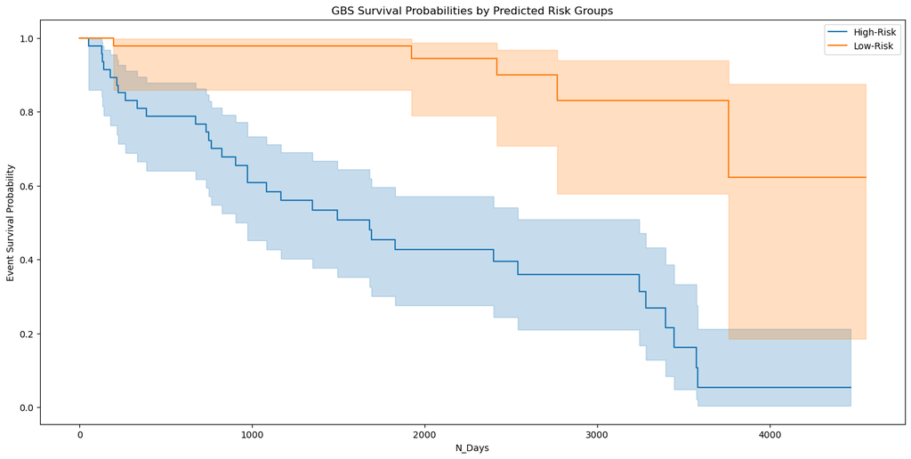

```python
##################################
# Binning the predicted risks
# into dichotomous groups and
# exploring the relationships with
# survival event and duration
##################################
cirrhosis_survival_test.reset_index(drop=True, inplace=True)
kmf = KaplanMeierFitter()
cirrhosis_survival_test['Predicted_Risks_GBS'] = optimal_gbs_cirrhosis_survival_y_test_pred
cirrhosis_survival_test['Predicted_RiskGroups_GBS'] = risk_groups = pd.qcut(cirrhosis_survival_test['Predicted_Risks_GBS'], 2, labels=['Low-Risk', 'High-Risk'])

plt.figure(figsize=(17, 8))
for group in risk_groups.unique():
    group_data = cirrhosis_survival_test[risk_groups == group]
    kmf.fit(group_data['N_Days'], event_observed=group_data['Status'], label=group)
    kmf.plot_survival_function()

plt.title('GBS Survival Probabilities by Predicted Risk Groups')
plt.xlabel('N_Days')
plt.ylabel('Event Survival Probability')
plt.show()
```

```python
##################################
# Gathering the predictor information
# for 5 test case samples
##################################
test_case_10 = cirrhosis_survival_X_test_preprocessed.iloc[[10, 20, 30, 40, 50]]
display(test_case_10)
```

|  | Age | Bilirubin | Cholesterol | Albumin | Copper | Alk_Phos | SGOT | Tryglicerides | Platelets | Prothrombin | Drug | Sex | Ascites | Hepatomegaly | Spiders | Edema | Stage_1.0 | Stage_2.0 | Stage_3.0 | Stage_4.0 |
| --- | --- | --- | --- | --- | --- | --- | --- | --- | --- | --- | --- | --- | --- | --- | --- | --- | --- | --- | --- | --- |
| 10 | 0.226982 | 1.530100 | 1.302295 | 1.331981 | 1.916467 | -0.477846 | -0.451305 | 2.250260 | 0.201024 | 0.546417 | 1 | 1 | 0 | 1 | 1 | 0 | 0 | 0 | 0 | 1 |
| 20 | -0.147646 | 0.061189 | 0.793618 | -1.158235 | 0.861264 | 0.625621 | 0.319035 | 0.446026 | 1.083875 | -1.508571 | 1 | 1 | 0 | 0 | 0 | 0 | 0 | 0 | 0 | 1 |
| 30 | 0.296370 | -1.283677 | 0.169685 | 3.237777 | -1.008276 | -0.873566 | -0.845549 | -0.351236 | 0.985206 | -0.617113 | 1 | 1 | 0 | 0 | 0 | 0 | 0 | 0 | 1 | 0 |
| 40 | 0.392609 | -0.096645 | -0.486337 | 1.903146 | -0.546292 | -0.247141 | -0.720619 | -0.810790 | -0.000298 | 1.402075 | 0 | 1 | 0 | 1 | 1 | 0 | 0 | 0 | 0 | 1 |
| 50 | -0.813646 | 1.089037 | 0.064451 | 0.212865 | 2.063138 | -0.224432 | 0.074987 | 2.333282 | 0.240640 | -1.125995 | 0 | 1 | 0 | 1 | 1 | 0 | 0 | 0 | 0 | 1 |

```python
##################################
# Gathering the event and duration information
# for 5 test case samples
##################################
print(cirrhosis_survival_y_test_array[[10, 20, 30, 40, 50]])
```

```
[( True, 1827) (False, 1447) (False, 2574) ( True, 3762) (False,  837)]
```

```python
##################################
# Gathering the risk-groups
# for 5 test case samples
##################################
print(cirrhosis_survival_test.loc[[10, 20, 30, 40, 50]][['Predicted_RiskGroups_GBS']])
```

```
   Predicted_RiskGroups_GBS
10                High-Risk
20                 Low-Risk
30                 Low-Risk
40                 Low-Risk
50                High-Risk
```

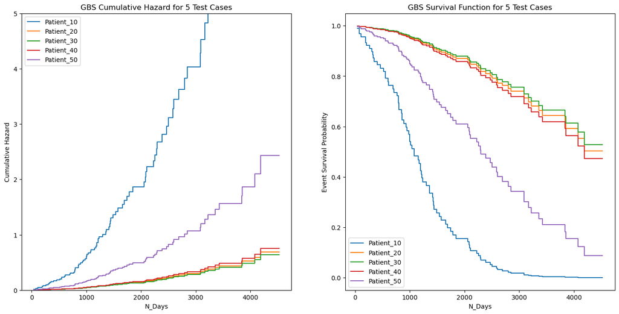

```python
##################################
# Estimating the cumulative hazard
# and survival functions
# for 5 test cases
##################################
test_case = cirrhosis_survival_X_test_preprocessed.iloc[[10, 20, 30, 40, 50]]
test_case_labels = ['Patient_10','Patient_20','Patient_30','Patient_40','Patient_50',]
test_case_cumulative_hazard_function = optimal_gbs_model.predict_cumulative_hazard_function(test_case)
test_case_survival_function = optimal_gbs_model.predict_survival_function(test_case)

fig, ax = plt.subplots(1,2,figsize=(17, 8))
for hazard_prediction, survival_prediction in zip(test_case_cumulative_hazard_function, test_case_survival_function):
    ax[0].step(hazard_prediction.x,hazard_prediction(hazard_prediction.x),where='post')
    ax[1].step(survival_prediction.x,survival_prediction(survival_prediction.x),where='post')
ax[0].set_title('GBS Cumulative Hazard for 5 Test Cases')
ax[0].set_xlabel('N_Days')
ax[0].set_ylim(0,5)
ax[0].set_ylabel('Cumulative Hazard')
ax[0].legend(test_case_labels, loc="upper left")
ax[1].set_title('GBS Survival Function for 5 Test Cases')
ax[1].set_xlabel('N_Days')
ax[1].set_ylabel('Event Survival Probability')
ax[1].legend(test_case_labels, loc="lower left")
plt.show()
```

## 1.7. Consolidated Findings

1. The choice of survival model will depend on a number of factors including assumptions, model complexity and variable selection capabilities.
   - [Cox proportional hazards regression](https://rss.onlinelibrary.wiley.com/doi/abs/10.1111/j.2517-6161.1972.tb00899.x) offers a simpler, well-understood, and straightforward interpretation, but assumes proportional hazards and may be less effective with high-dimensional data.
   - [Cox net survival](https://doi.org/10.18637/jss.v039.i05) handles high-dimensional data, performs variable selection, and manages multicollinearity, but may be more complex and requires parameter tuning.
   - [Survival trees](https://www.tandfonline.com/doi/abs/10.1080/01621459.1993.10476296) require no assumptions about survival time distribution and naturally capture interactions, but may be prone to overfitting and less accurate.
   - [Random survival forest](https://projecteuclid.org/journals/annals-of-applied-statistics/volume-2/issue-3/Random-survival-forests/10.1214/08-AOAS169.full) is robust against high-dimensional data and provides variable importance, but may be computationally intensive and less interpretable.
   - [Gradient boosted survival](https://projecteuclid.org/journals/annals-of-statistics/volume-29/issue-5/Greedy-function-approximation-A-gradient-boosting-machine/10.1214/aos/1013203451.full) models complex relationships while reducing bias and variance, but may be highly computationally intensive, needs complex tuning and requires challenging interpretation.
2. Comparing all results from the survival models formulated, the viable models for prediction can be any of the following:
   - [Random survival forest](https://projecteuclid.org/journals/annals-of-applied-statistics/volume-2/issue-3/Random-survival-forests/10.1214/08-AOAS169.full)
     - Demonstrated the best independent cross-validated (**Concordance Index** = 0.8214) and test (**Concordance Index** = 0.8761) model performance
     - Showed considerable overfit between the train (**Concordance Index** = 0.9153) and cross-validated (**Concordance Index** = 0.8214) model performance
     - Demonstrated good survival profile differentiation between the risk groups
     - Allows for the estimation of permutation-based variable importance which might aid in better interpretation
   - [Cox proportional hazards regression](https://rss.onlinelibrary.wiley.com/doi/abs/10.1111/j.2517-6161.1972.tb00899.x)
     - Demonstrated the second highest independent cross-validated (**Concordance Index** = 0.8136) and test (**Concordance Index** = 0.8743) model performance
     - Showed minimal overfit between the train (**Concordance Index** = 0.8485) and cross-validated (**Concordance Index** = 0.8136) model performance
     - Demonstrated good survival profile differentiation between the risk groups
     - Allows for the estimation of absolute coefficient-based variable importance which might aid in better interpretation
3. The feature importance evaluation for the [random survival forest](https://projecteuclid.org/journals/annals-of-applied-statistics/volume-2/issue-3/Random-survival-forests/10.1214/08-AOAS169.full) and [cox proportional hazards regression](https://rss.onlinelibrary.wiley.com/doi/abs/10.1111/j.2517-6161.1972.tb00899.x) determined the following predictors as the most relevant during prediction:
   - Bilirubin
   - Prothrombin

```python
##################################
# Consolidating all the
# model performance metrics
##################################
model_performance_comparison = pd.concat([coxph_summary,
                                          coxns_summary,
                                          stree_summary,
                                          rsf_summary,
                                          gbs_summary],
                                         axis=0,
                                         ignore_index=True)
print('Survival Model Comparison: ')
display(model_performance_comparison)
```

```
Survival Model Comparison:
```

|  | Set | Concordance.Index | Method |
| --- | --- | --- | --- |
| 0 | Train | 0.848586 | COXPH |
| 1 | Cross-Validation | 0.813656 | COXPH |
| 2 | Test | 0.874376 | COXPH |
| 3 | Train | 0.847204 | COXNS |
| 4 | Cross-Validation | 0.812264 | COXNS |
| 5 | Test | 0.871655 | COXNS |
| 6 | Train | 0.864678 | STREE |
| 7 | Cross-Validation | 0.793183 | STREE |
| 8 | Test | 0.817460 | STREE |
| 9 | Train | 0.915312 | RSF |
| 10 | Cross-Validation | 0.821493 | RSF |
| 11 | Test | 0.876190 | RSF |
| 12 | Train | 0.928072 | GBS |
| 13 | Cross-Validation | 0.805171 | GBS |
| 14 | Test | 0.865760 | GBS |

```python
##################################
# Consolidating the concordance indices
# for all sets and models
##################################
set_labels = ['Train','Test']
coxph_ci = model_performance_comparison[((model_performance_comparison['Set'] == 'Train') |
                                         (model_performance_comparison['Set'] == 'Cross-Validation') |
                                         (model_performance_comparison['Set'] == 'Test')) &
                                        (model_performance_comparison['Method']=='COXPH')]['Concordance.Index'].values
coxns_ci = model_performance_comparison[((model_performance_comparison['Set'] == 'Train') |
                                         (model_performance_comparison['Set'] == 'Cross-Validation') |
                                         (model_performance_comparison['Set'] == 'Test')) &
                                        (model_performance_comparison['Method']=='COXNS')]['Concordance.Index'].values
stree_ci = model_performance_comparison[((model_performance_comparison['Set'] == 'Train') |
                                         (model_performance_comparison['Set'] == 'Cross-Validation') |
                                         (model_performance_comparison['Set'] == 'Test')) &
                                        (model_performance_comparison['Method']=='STREE')]['Concordance.Index'].values
rsf_ci = model_performance_comparison[((model_performance_comparison['Set'] == 'Train') |
                                         (model_performance_comparison['Set'] == 'Cross-Validation') |
                                         (model_performance_comparison['Set'] == 'Test')) &
                                        (model_performance_comparison['Method']=='RSF')]['Concordance.Index'].values
gbs_ci = model_performance_comparison[((model_performance_comparison['Set'] == 'Train') |
                                         (model_performance_comparison['Set'] == 'Cross-Validation') |
                                         (model_performance_comparison['Set'] == 'Test')) &
                                        (model_performance_comparison['Method']=='GBS')]['Concordance.Index'].values
```

```python
##################################
# Plotting the values for the
# concordance indices
# for all models
##################################
ci_plot = pd.DataFrame({'COXPH': list(coxph_ci),
                        'COXNS': list(coxns_ci),
                        'STREE': list(stree_ci),
                        'RSF': list(rsf_ci),
                        'GBS': list(gbs_ci)},
                       index=['Train','Cross-Validation','Test'])
display(ci_plot)
```

|  | COXPH | COXNS | STREE | RSF | GBS |
| --- | --- | --- | --- | --- | --- |
| Train | 0.848586 | 0.847204 | 0.864678 | 0.915312 | 0.928072 |
| Cross-Validation | 0.813656 | 0.812264 | 0.793183 | 0.821493 | 0.805171 |
| Test | 0.874376 | 0.871655 | 0.817460 | 0.876190 | 0.865760 |

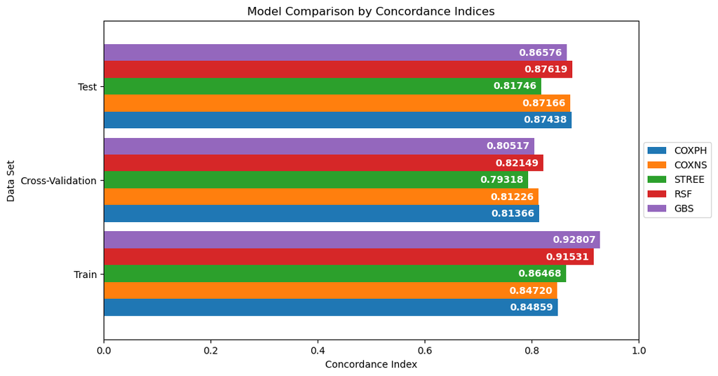

```python
##################################
# Plotting all the concordance indices
# for all models
##################################
ci_plot = ci_plot.plot.barh(figsize=(10, 6), width=0.90)
ci_plot.set_xlim(0.00,1.00)
ci_plot.set_title("Model Comparison by Concordance Indices")
ci_plot.set_xlabel("Concordance Index")
ci_plot.set_ylabel("Data Set")
ci_plot.grid(False)
ci_plot.legend(loc='center left', bbox_to_anchor=(1.0, 0.5))
for container in ci_plot.containers:
    ci_plot.bar_label(container, fmt='%.5f', padding=-50, color='white', fontweight='bold')
```

```python
##################################
# Determining the Random Survival Forest model
# permutation-based feature importance
# on train data
##################################
rfs_train_feature_importance = permutation_importance(optimal_rsf_model,
                                                cirrhosis_survival_X_train_preprocessed,
                                                cirrhosis_survival_y_train_array,
                                                n_repeats=15,
                                                random_state=88888888)

rsf_train_feature_importance_summary = pd.DataFrame(
    {k: rfs_train_feature_importance[k]
     for k in ("importances_mean", "importances_std")},
    index=cirrhosis_survival_X_train_preprocessed.columns).sort_values(by="importances_mean", ascending=False)
rsf_train_feature_importance_summary.columns = ['Importances.Mean', 'Importances.Std']
display(rsf_train_feature_importance_summary)
```

|  | Importances.Mean | Importances.Std |
| --- | --- | --- |
| Bilirubin | 0.059856 | 0.011472 |
| Prothrombin | 0.024225 | 0.003892 |
| Copper | 0.023109 | 0.006796 |
| Age | 0.017452 | 0.002394 |
| Cholesterol | 0.016569 | 0.002951 |
| Albumin | 0.013622 | 0.002659 |
| Tryglicerides | 0.008306 | 0.001162 |
| Platelets | 0.008008 | 0.002287 |
| SGOT | 0.006323 | 0.001263 |
| Alk_Phos | 0.005998 | 0.001509 |
| Ascites | 0.004465 | 0.001230 |
| Stage_4.0 | 0.003917 | 0.001752 |
| Hepatomegaly | 0.003506 | 0.001303 |
| Edema | 0.001566 | 0.001421 |
| Sex | 0.001143 | 0.000559 |
| Drug | 0.001127 | 0.000356 |
| Stage_3.0 | 0.001046 | 0.000351 |
| Spiders | 0.000769 | 0.000515 |
| Stage_2.0 | 0.000498 | 0.000257 |
| Stage_1.0 | 0.000108 | 0.000064 |

```python
##################################
# Determining the Cox Proportional Hazards Regression model
# absolute coefficient-based feature importance
# on train data
##################################
feature_importance_df = pd.DataFrame({
    'Signed.Coefficient': optimal_coxph_model.coef_,
    'Absolute.Coefficient': np.abs(optimal_coxph_model.coef_),
}, index=cirrhosis_survival_X_train_preprocessed.columns)
display(feature_importance_df.sort_values('Absolute.Coefficient', ascending=False))
```

|  | Signed.Coefficient | Absolute.Coefficient |
| --- | --- | --- |
| Bilirubin | 0.624673 | 0.624673 |
| Prothrombin | 0.349448 | 0.349448 |
| Age | 0.309594 | 0.309594 |
| Edema | 0.304485 | 0.304485 |
| Stage_4.0 | 0.167935 | 0.167935 |
| Albumin | -0.166835 | 0.166835 |
| SGOT | 0.160465 | 0.160465 |
| Stage_1.0 | -0.144274 | 0.144274 |
| Copper | 0.137420 | 0.137420 |
| Tryglicerides | 0.122772 | 0.122772 |
| Drug | -0.122633 | 0.122633 |
| Ascites | 0.081358 | 0.081358 |
| Hepatomegaly | 0.077079 | 0.077079 |
| Platelets | -0.071638 | 0.071638 |
| Stage_2.0 | -0.066467 | 0.066467 |
| Cholesterol | 0.049194 | 0.049194 |
| Sex | 0.045557 | 0.045557 |
| Stage_3.0 | 0.042805 | 0.042805 |
| Spiders | 0.022839 | 0.022839 |
| Alk_Phos | 0.015004 | 0.015004 |

# 2. Summary

# 3. References

- **[Book]** [Clinical Prediction Models](http://clinicalpredictionmodels.org/) by Ewout Steyerberg
- **[Book]** [Survival Analysis: A Self-Learning Text](https://link.springer.com/book/10.1007/978-1-4419-6646-9/) by David Kleinbaum and Mitchel Klein
- **[Book]** [Applied Survival Analysis Using R](https://link.springer.com/book/10.1007/978-3-319-31245-3/) by Dirk Moore
- **[Python Library API]** [SciKit-Survival](https://pypi.org/project/scikit-survival/) by SciKit-Survival Team
- **[Python Library API]** [SciKit-Learn](https://scikit-learn.org/stable/index.html) by SciKit-Learn Team
- **[Python Library API]** [StatsModels](https://www.statsmodels.org/stable/index.html) by StatsModels Team
- **[Python Library API]** [SciPy](https://scipy.org/) by SciPy Team
- **[Python Library API]** [Lifelines](https://lifelines.readthedocs.io/en/latest/) by Lifelines Team
- **[Article]** [Exploring Time-to-Event with Survival Analysis](https://towardsdatascience.com/exploring-time-to-event-with-survival-analysis-8b0a7a33a7be) by Olivia Tanuwidjaja (Towards Data Science)
- **[Article]** [The Complete Introduction to Survival Analysis in Python](https://towardsdatascience.com/the-complete-introduction-to-survival-analysis-in-python-7523e17737e6) by Marco Peixeiro (Towards Data Science)
- **[Article]** [Survival Analysis Simplified: Explaining and Applying with Python](https://medium.com/@zynp.atlii/survival-analysis-simplified-explaining-and-applying-with-python-7efacf86ba32) by Zeynep Atli (Towards Data Science)
- **[Article]** [Survival Analysis in Python (KM Estimate, Cox-PH and AFT Model)](https://medium.com/the-researchers-guide/survival-analysis-in-python-km-estimate-cox-ph-and-aft-model-5533843c5d5d) by Rahul Raoniar (Medium)
- **[Article]** [How to Evaluate Survival Analysis Models)](https://towardsdatascience.com/how-to-evaluate-survival-analysis-models-dd67bc10caae) by Nicolo Cosimo Albanese (Towards Data Science)
- **[Article]** [Survival Analysis with Python Tutorial — How, What, When, and Why)](https://pub.towardsai.net/survival-analysis-with-python-tutorial-how-what-when-and-why-19a5cfb3c312) by Towards AI Team (Medium)
- **[Article]** [Survival Analysis: Predict Time-To-Event With Machine Learning)](https://towardsdatascience.com/survival-analysis-predict-time-to-event-with-machine-learning-part-i-ba52f9ab9a46) by Lina Faik (Medium)
- **[Article]** [A Complete Guide To Survival Analysis In Python, Part 1](https://www.kdnuggets.com/2020/07/complete-guide-survival-analysis-python-part1.html) by Pratik Shukla (KDNuggets)
- **[Article]** [A Complete Guide To Survival Analysis In Python, Part 2](https://www.kdnuggets.com/2020/07/guide-survival-analysis-python-part-2.html) by Pratik Shukla (KDNuggets)
- **[Article]** [A Complete Guide To Survival Analysis In Python, Part 3](https://www.kdnuggets.com/2020/07/guide-survival-analysis-python-part-3.html) by Pratik Shukla (KDNuggets)
- **[Kaggle Project]** [Survival Analysis with Cox Model Implementation](https://www.kaggle.com/code/bryanb/survival-analysis-with-cox-model-implementation/notebook) by Bryan Boulé (Kaggle)
- **[Kaggle Project]** [Survival Analysis](https://www.kaggle.com/code/gunesevitan/survival-analysis/notebook) by Gunes Evitan (Kaggle)
- **[Kaggle Project]** [Survival Analysis of Lung Cancer Patients](https://www.kaggle.com/code/bryanb/survival-analysis-with-cox-model-implementation/notebook) by Sayan Chakraborty (Kaggle)
- **[Kaggle Project]** [COVID-19 Cox Survival Regression](https://www.kaggle.com/code/bryanb/survival-analysis-with-cox-model-implementation/notebook) by Ilias Katsabalos (Kaggle)
- **[Kaggle Project]** [Liver Cirrhosis Prediction with XGboost & EDA](https://www.kaggle.com/code/arjunbhaybhang/liver-cirrhosis-prediction-with-xgboost-eda) by Arjun Bhaybang (Kaggle)
- **[Kaggle Project]** [Survival Models VS ML Models Benchmark - Churn Tel](https://www.kaggle.com/code/caralosal/survival-models-vs-ml-models-benchmark-churn-tel) by Carlos Alonso Salcedo (Kaggle)
- **[Publication]** [Regression Models and Life Tables](https://rss.onlinelibrary.wiley.com/doi/abs/10.1111/j.2517-6161.1972.tb00899.x) by David Cox (Royal Statistical Society)
- **[Publication]** [Covariance Analysis of Censored Survival Data](https://pubmed.ncbi.nlm.nih.gov/4813387/) by Norman Breslow (Biometrics)
- **[Publication]** [The Efficiency of Cox’s Likelihood Function for Censored Data](https://www.jstor.org/stable/2286217) by Bradley Efron (Journal of the American Statistical Association)
- **[Publication]** [Regularization Paths for Cox’s Proportional Hazards Model via Coordinate Descent](https://doi.org/10.18637/jss.v039.i05) by Noah Simon, Jerome Friedman, Trevor Hastie and Rob Tibshirani (Journal of Statistical Software)
- **[Publication]** [Survival Trees by Goodness of Split](https://www.tandfonline.com/doi/abs/10.1080/01621459.1993.10476296) by Michael LeBlanc and John Crowley (Journal of the American Statistical Association)
- **[Publication]** [Random Survival Forests](https://projecteuclid.org/journals/annals-of-applied-statistics/volume-2/issue-3/Random-survival-forests/10.1214/08-AOAS169.full) by Hemant Ishwaran, Udaya Kogalur, Eugene Blackstone and Michael Lauer (Annals of Applied Statistics)
- **[Publication]** [Survival Ensembles](https://academic.oup.com/biostatistics/article/7/3/355/248945) by Torsten Hothorn, Peter Bühlmann, Sandrine Dudoit, Annette Molinaro and Mark Van Der Laan (Biostatistics)
- **[Publication]** [The State of Boosting](https://www.semanticscholar.org/paper/The-State-of-Boosting-%E2%88%97-Ridgeway/1aac6453fbb8333ee638b6d8b2bb2aff06c3654b) by Greg Ridgeway (Computing Science and Statistics)
- **[Publication]** [Stochastic Gradient Boosting](https://www.sciencedirect.com/science/article/abs/pii/S0167947301000652) by Jerome Friedman (Computational Statitics and Data Analysis)
- **[Publication]** [Greedy Function Approximation: A Gradient Boosting Machine](https://projecteuclid.org/journals/annals-of-statistics/volume-29/issue-5/Greedy-function-approximation-A-gradient-boosting-machine/10.1214/aos/1013203451.full) by Jerome Friedman (The Annals of Statistics)
- **[Publication]** [Survival Analysis Part I: Basic Concepts and First Analyses](https://www.ncbi.nlm.nih.gov/pmc/articles/PMC2394262/) by Taane Clark (British Journal of Cancer)
- **[Publication]** [Survival Analysis Part II: Multivariate Data Analysis – An Introduction to Concepts and Methods](https://www.ncbi.nlm.nih.gov/pmc/articles/PMC2394368/) by Mike Bradburn (British Journal of Cancer)
- **[Publication]** [Survival Analysis Part III: Multivariate Data Analysis – Choosing a Model and Assessing its Adequacy and Fit](https://www.ncbi.nlm.nih.gov/pmc/articles/PMC2376927/) by Mike Bradburn (British Journal of Cancer)
- **[Publication]** [Survival Analysis Part IV: Further Concepts and Methods in Survival Analysis](https://www.ncbi.nlm.nih.gov/pmc/articles/PMC2394469/) by Taane Clark (British Journal of Cancer)
- **[Course]** [Survival Analysis in Python](https://app.datacamp.com/learn/courses/survival-analysis-in-python) by Shae Wang (DataCamp)

```python
from IPython.display import display, HTML
display(HTML("<style>.rendered_html { font-size: 15px; font-family: 'Trebuchet MS'; }</style>"))
```